# Digit blastema characterization through bioimage analysis

Melissa Miller

```r
library(csv)
library(xlsx)
library(dplyr)
library(tidyverse)
library(tools)
library(plotly)
library(RColorBrewer)
library(stats)
library(ggpattern)
library(scales)
library(ggrepel)
```

The work below was done in support of (Griffiths et al. 2025). The overall goal of this work was to characterize the regenerating axolotl digit blastema and its similarity to the regenerating limb blastema. The analyses presented below can also be applied to various projects utilizing fluorescence microscopy.

## Figure 1, S4

The first goal of characterizing the digit blastema was to assess whether the regenerating digit expresses the same genes we expect blastemal cells to express. These include genes associated with connective tissue de- and re-differentiation, tissue patterning, and several developmental pathways such as *Wnt*.

### qPCR

Below is an analysis of qPCR data to quantify the presence of, in this case, Indian hedgehog ( *Ihh* ), which is important for joint morphogenesis. Results of this analysis, as well as for many other genes, are published in (Griffiths et al. 2025).

#### Data processing

Data used here derives from qPCR targeting *Ihh* in several regenerating tissues. The regenerating wrist is used as a control against which regenerating digits are compared. The axolotl forelimb has four digits, and each are quantified independently for *Ihh* expression owing to potential anterior-posterior expression differences.

##### Raw data

```r
ihh <- read.csv("../knitData/ihh.csv") %>%
  select(1,2,4) %>%
  `colnames<-`(c("Sample", "Target", "CqMean"))
```

|  | Sample | Target | CqMean |
| --- | --- | --- | --- |
| 1 | Blast_1 | Ef1a | 21.27631 |
| 2 | Blast_1 | Ihh | 32.33187 |
| 3 | Blast_2 | Ef1a | 22.31782 |
| 4 | Blast_2 | Ihh | NA |
| 5 | Blast_3 | Ef1a | 21.78816 |
| 6 | Blast_3 | Ihh | 38.73181 |

##### Preparing plot data

```r
ihh <- ihh %>%
  filter(str_detect(Sample,"Met_",negate = T)) %>%
  mutate(Replicate = gsub("^.*_","",Sample)) %>%
  mutate(Sample = gsub("_.*$","",Sample)) %>%
  mutate(Sample = case_when(Sample == "Digit 1" ~ "DI",
                            Sample == "Digit 2" ~ "DII",
                            Sample == "Digit 3" ~ "DIII",
                            Sample == "Digit 4" ~ "DIV",
                            Sample == "Blast" ~ "Wrist")) %>%
  mutate(CqMean = case_when(is.na(CqMean) ~ 40,
                            TRUE ~ CqMean)) %>% # Non-detectable expression is assigned 40
  pivot_wider(., names_from = Target, values_from = CqMean)

ihh <- ihh %>%
  mutate(deltaCt = Ihh-Ef1a) %>%
  filter(Ef1a < 30)
```

| Sample | Replicate | Ef1a | Ihh | deltaCt |
| --- | --- | --- | --- | --- |
| Wrist | 1 | 21.27631 | 32.33187 | 11.05556 |
| Wrist | 2 | 22.31782 | 40.00000 | 17.68218 |
| Wrist | 3 | 21.78816 | 38.73181 | 16.94365 |
| Wrist | 4 | 20.68676 | 35.47630 | 14.78954 |
| DI | 3 | 19.36117 | 36.55172 | 17.19055 |
| DII | 1 | 19.81827 | 35.13220 | 15.31393 |

```r
# Used to calculate deltaDeltaCt, a measure of expression change compared to control
std.val <- ihh %>%
  filter(Sample == "Wrist") %>%
  select(deltaCt) %>%
  mutate(deltaCt = as.numeric(deltaCt)) %>%
  as.list() %>% unlist() %>%
  mean()

ihh <- ihh %>%
  mutate(deltaDeltaCt = as.numeric(deltaCt)-std.val) %>%
  mutate(logFoldChange = 2^(-1*deltaDeltaCt))
```

| Sample | Replicate | Ef1a | Ihh | deltaCt | deltaDeltaCt | logFoldChange |
| --- | --- | --- | --- | --- | --- | --- |
| Wrist | 1 | 21.27631 | 32.33187 | 11.05556 | -4.0621722 | 16.7045842 |
| Wrist | 2 | 22.31782 | 40.00000 | 17.68218 | 2.5644453 | 0.1690538 |
| Wrist | 3 | 21.78816 | 38.73181 | 16.94365 | 1.8259173 | 0.2820617 |
| Wrist | 4 | 20.68676 | 35.47630 | 14.78954 | -0.3281904 | 1.2554377 |
| DI | 3 | 19.36117 | 36.55172 | 17.19055 | 2.0728207 | 0.2376943 |
| DII | 1 | 19.81827 | 35.13220 | 15.31393 | 0.1962038 | 0.8728443 |

#### Analysis

##### Plot

This plots depicts the expression of *Ihh* across samples on a log-10 scale, relative to the expression of *Ef1a*.

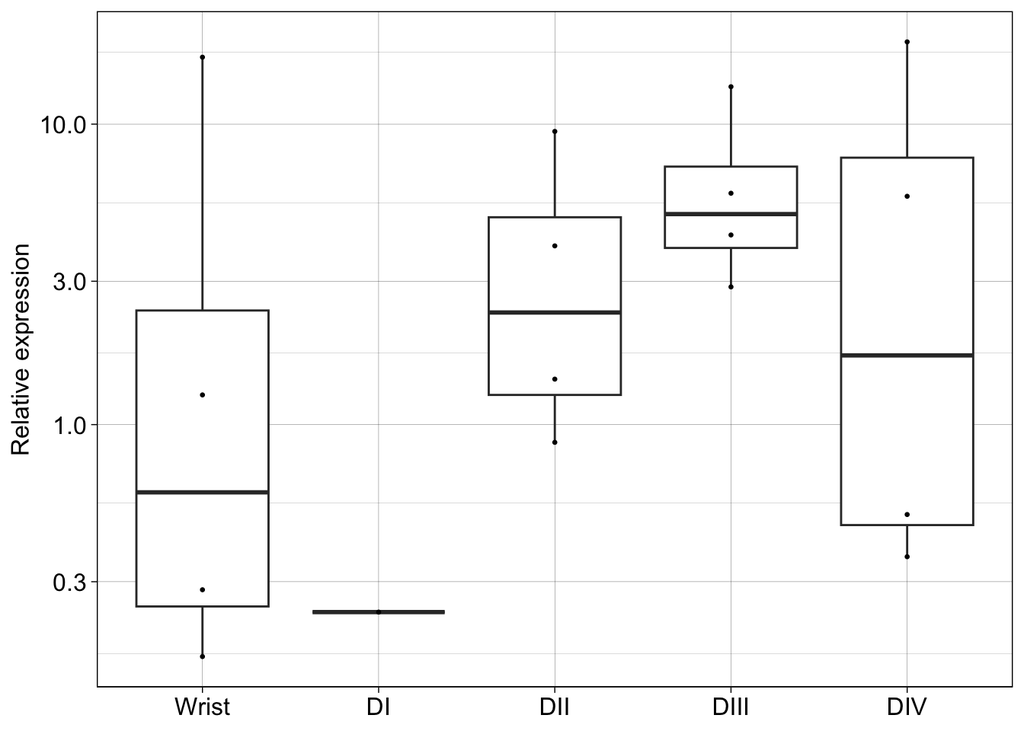

```r
ggplot(ihh, aes(x = factor(Sample, levels = c("Wrist", "DI", "DII", "DIII", "DIV")),
                 y = logFoldChange)) +
  geom_hline(yintercept = 0, linewidth = 0.5) +
  geom_boxplot(outliers = FALSE) +
  geom_point(size = 0.5) +
  xlab(NULL) +
  ylab("Relative expression") +
  theme_linedraw() +
  scale_y_log10() +
  theme(axis.text = element_text(family = "Arial", color = "black", size = 12),
        axis.title = element_text(family = "Arial", color = "black", size = 12),
        panel.border = element_rect(linewidth = 0.5))
```

##### Parametric testing

Statistical testing is performed on the expression of *Ihh* in each sample relative to *Ef1a*. One-way ANOVA was performed to identify differences in the group, followed by a *post hoc* Tukey test as necessary. In this case, there is no statistically significant difference indicated by the ANOVA, so a *post hoc* test is not performed.

```r
ihh.lm <- aov(deltaCt ~ Sample,
                  data = ihh)
anova(ihh.lm)
```

|  | Df | Sum Sq | Mean Sq | F value | Pr(>F) |
| --- | --- | --- | --- | --- | --- |
| Sample | 4 | 22.75955 | 5.689887 | 1.15694 | 0.377206 |
| Residuals | 12 | 59.01657 | 4.918048 | NA | NA |

##### Nonparametric testing

Although not used in this publication, nonparametric tests can also be used to analyze qPCR data. Similarly to the parametric tests, there is no significant difference among groups, so the pairwise Wilcox test *post hoc* is not necessary.

```r
kruskal.test(deltaCt ~ Sample,
             data = ihh)
```

```
##
##  Kruskal-Wallis rank sum test
##
## data:  deltaCt by Sample
## Kruskal-Wallis chi-squared = 4.2059, df = 4, p-value = 0.3789
```

## Figure 2

Given that forelimb regeneration is dependent on an intact nerve supply, the next goal was to demonstrate that digit regeneration is similarly nerve dependent.

### mAG vs mCherry

The purpose of this analysis is to partly assess the response of the digit blastema to denervation. Denervation of the regenerating limb leads to a loss in cell cycling and delayed or failed regeneration. Images were taken of a transgenic FUCCI line of animals wherein cells in S or G2 express mAG and cells in G1 express mCherry (Duerr et al. 2022).

#### Preparing data

A timecourse was captured in regenerating innervated and denervated digits from FUCCI animals. Images of digit blastemas were segmented with Cellpose [(Stringer et al. 2021), (Pachitariu and Stringer 2022), (Stringer and Pachitariu 2025)]. The resulting text outlines were used to measure fluorescence intensity in the mAG and mCherry channels. The measurements were used to classify cells as mAG or mCherry positive as an indication of their cell cycle state.

```r
summary.stats <- read.xlsx("../knitData/mesenchyme_stats.xlsx",
                           sheetIndex = 1)

summary.stats <- summary.stats %>%
  group_by(Animal, Treatment, Timepoint) %>%
  mutate(total_cells = sum(mAG_total, mCherry_total)) %>%
  mutate(prop_mAG = (mAG_total/total_cells)*100,
         prop_mCherry = (mCherry_total/total_cells)*100)
```

| Animal | Treatment | Timepoint | mAG_total | mCherry_total | total_cells | prop_mAG | prop_mCherry |
| --- | --- | --- | --- | --- | --- | --- | --- |
| 5 | Dnv | 0 | 230 | 699 | 929 | 24.7578041 | 75.24220 |
| 5 | Dnv | 1 | 146 | 504 | 650 | 22.4615385 | 77.53846 |
| 5 | Dnv | 2 | 157 | 779 | 936 | 16.7735043 | 83.22650 |
| 5 | Dnv | 3 | 46 | 447 | 493 | 9.3306288 | 90.66937 |
| 5 | Dnv | 4 | 19 | 358 | 377 | 5.0397878 | 94.96021 |
| 5 | Dnv | 5 | 3 | 324 | 327 | 0.9174312 | 99.08257 |

The data were further processed for the average number of cells in each condition expressing mAG or mCherry.

```r
chart.data <- summary.stats %>%
  ungroup() %>%
  pivot_longer(., c(4,5), names_to = "Channel") %>%
  mutate(Channel = case_when(Channel == "mAG_total" ~ "mAG",
                             TRUE ~ "mCherry")) %>%
  select(1:3, 7:8, 4:6)

colnames(chart.data) <- c(colnames(chart.data)[1:4], "Count", colnames(chart.data)[6:8])

chart.data <- chart.data %>%
  mutate(Treatment = case_when(Treatment == "Dnv" ~ "Denervated",
                               TRUE ~ "Innervated")) %>%
  rename("Innervation" = "Treatment")
```

```r
count.averages <- chart.data %>%
  select(1:6) %>%
  group_by(Innervation, Timepoint, Channel) %>%
  mutate(Average_Total = mean(Count),
         Innervation = case_when(Innervation == "Innervated" ~ "INV",
                                 TRUE ~ "DNV"),
         Timepoint = case_when(Timepoint == 0 ~ 6,
                               Timepoint == 1 ~ 9,
                               Timepoint == 2 ~ 12,
                               Timepoint == 3 ~ 15,
                               Timepoint == 4 ~ 18,
                               TRUE ~ 21)) %>%
  ungroup() %>%
  dplyr::select(Channel, Innervation, Timepoint, Average_Total) %>%
  unique() %>%
  dplyr::rename(Average = Average_Total)
```

| Channel | Innervation | Timepoint | Average |
| --- | --- | --- | --- |
| mAG | DNV | 6 | 259.75 |
| mCherry | DNV | 6 | 706.25 |
| mAG | DNV | 9 | 149.75 |
| mCherry | DNV | 9 | 563.00 |
| mAG | DNV | 12 | 127.00 |
| mCherry | DNV | 12 | 580.25 |

#### INV vs. DNV cell cycling timecourse

This chart shows that following amputation, innervated digits display a small, transitory loss in cell cycling associated with tissue degradation, followed by a “recovery”. In contrast, denervated digits do not display this same recovery, and the proportion of cycling cells continues to decline as cells arrest in G1.

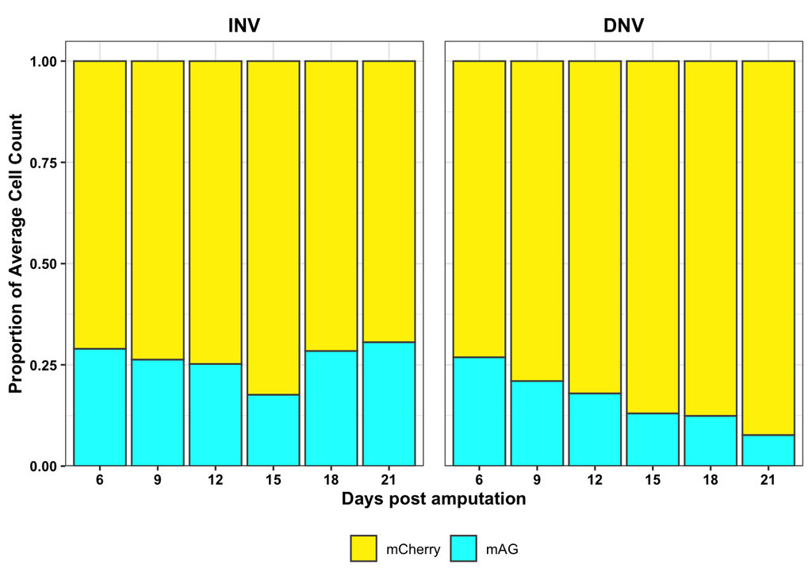

```r
ggplot(count.averages,
               aes(x = factor(Timepoint, levels = c(6,9,12,15,18,21)),
                   y = Average,
                   fill = factor(Channel,
                                 levels = c("mCherry", "mAG")))) +
  geom_bar(stat = "identity",
           position = position_fill(),
           width = 0.9,
           colour = "gray30") +
  facet_grid(cols = vars(factor(Innervation,
                                levels = c("INV", "DNV")))) +
  xlab("Days post amputation") +
  ylab("Proportion of Average Cell Count") +
  theme_bw() +
  scale_fill_manual(values = c("#FFF000", "#00FFFF")) +
  theme(legend.title = element_blank(),
        legend.position = "bottom",
        panel.spacing.x = unit(0.9, "lines"),
        strip.background = element_rect(fill = "white", linewidth = 0),
        strip.text.x = element_text(family = "Arial", face = "bold",
                                    color = "black", size = 12),
        axis.text = element_text(face = "bold", colour = "black"),
        axis.title.y = element_text(face = "bold",
                                    colour = "black",
                                    family = "Arial"),
        axis.title.x = element_text(face = "bold",
                                    colour = "black",
                                    family = "Arial")) +
  scale_y_continuous(expand = expansion(mult = c(0, 0.05)))
```

#### Cell cycling timecourse statistics

We are interested in showing that there is no significant difference in the proportion of cycling cells at any time in the innervated digits, depicted below.

```r
summary.INV <- summary.stats %>%
  filter(Treatment == "Inv") %>%
  arrange(Timepoint)
```

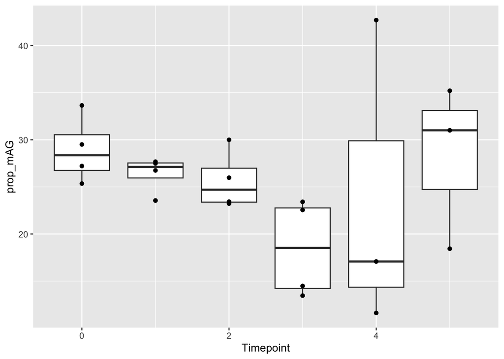

```r
ggplot(summary.INV, aes(x = Timepoint, y = prop_mAG, group = Timepoint)) +
  geom_boxplot() +
  geom_point()
```

Using a Kruskal-Wallis rank-sum test, we conclude that there is no significant difference in the proportion of cycling cells between any timepoints in innervated samples.

```r
kruskal.test(prop_mAG ~ Timepoint, summary.INV)
```

```
##
##  Kruskal-Wallis rank sum test
##
## data:  prop_mAG by Timepoint
## Kruskal-Wallis chi-squared = 7.5356, df = 5, p-value = 0.1838
```

For the denervated, we hope to determine that there is a difference in the proportion of cycling cells, namely that the proportion continually decreases and is significantly lower at later timepoints than in the first collection.

```r
summary.DNV <- summary.stats %>%
  filter(Treatment == "Dnv") %>%
  arrange(Timepoint)
```

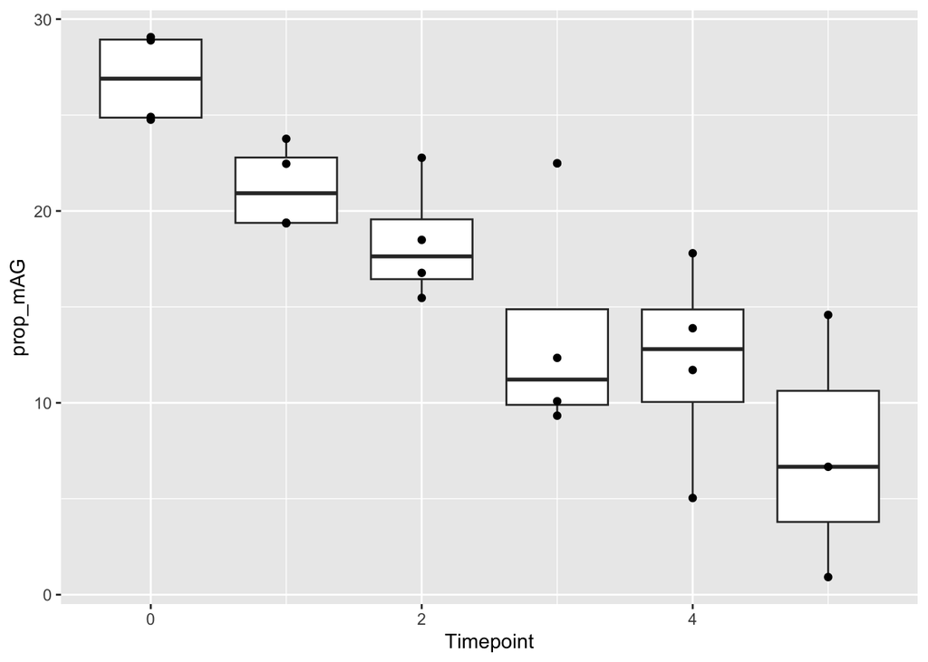

```r
ggplot(summary.DNV, aes(x = Timepoint, y = prop_mAG, group = Timepoint)) +
  geom_boxplot() +
  geom_point()
```

The Kruskal-Wallis test indicates that there exists significant differences in the proportion of cycling cells between timepoints.

```r
kruskal.test(prop_mAG ~ Timepoint, summary.DNV)
```

```
##
##  Kruskal-Wallis rank sum test
##
## data:  prop_mAG by Timepoint
## Kruskal-Wallis chi-squared = 16.556, df = 5, p-value = 0.005423
```

Because we want to see that there is a significant decrease in the proportion of cycling cells between time 0 (6dpa) and time 5 (21dpa), we perform a Wilcoxon rank sum exact test with a “g” alternative. We find that the proportion of cycling cells at time 0 is significantly greater than the proportion of cycling cells at time 5, supporting our earlier conclusion that denervated digits do not display a “recovery” in G1 arrest.

```r
wilcox.test(summary.DNV[summary.DNV$Timepoint == 0,]$prop_mAG,
            summary.DNV[summary.DNV$Timepoint == 5,]$prop_mAG,
            p.adjust = "fdr",
            alternative = "g")
```

```
##
##  Wilcoxon rank sum exact test
##
## data:  summary.DNV[summary.DNV$Timepoint == 0, ]$prop_mAG and summary.DNV[summary.DNV$Timepoint == 5, ]$prop_mAG
## W = 12, p-value = 0.02857
## alternative hypothesis: true location shift is greater than 0
```

#### INV vs. DNV cell count timecourse

Taking what we found with regard to the G1 arrest seen in denervated digits, we wanted to show that there is a similar loss in the total cells present in the tissue over time as denervated tissue degrades.

```r
totals <- chart.data %>%
  select(Animal, Innervation, Timepoint, total_cells) %>%
  unique() %>%
  mutate(Timepoint = case_when(Timepoint == 0 ~ 6,
                               Timepoint == 1 ~ 9,
                               Timepoint == 2 ~ 12,
                               Timepoint == 3 ~ 15,
                               Timepoint == 4 ~ 18,
                               TRUE ~ 21) %>% as.character())
```

| Animal | Innervation | Timepoint | total_cells |
| --- | --- | --- | --- |
| 5 | Denervated | 6 | 929 |
| 5 | Denervated | 9 | 650 |
| 5 | Denervated | 12 | 936 |
| 5 | Denervated | 15 | 493 |
| 5 | Denervated | 18 | 377 |
| 5 | Denervated | 21 | 327 |

This chart shows that in the denervated samples, the total number of cells in the tissue continues to drop over time, aligning with the observed G1 arrest. In innervated samples, there is moderate tissue degradation as injured cells are cleared out, but this is followed by a rebound in cell cycling which leads to an increased number of cells present.

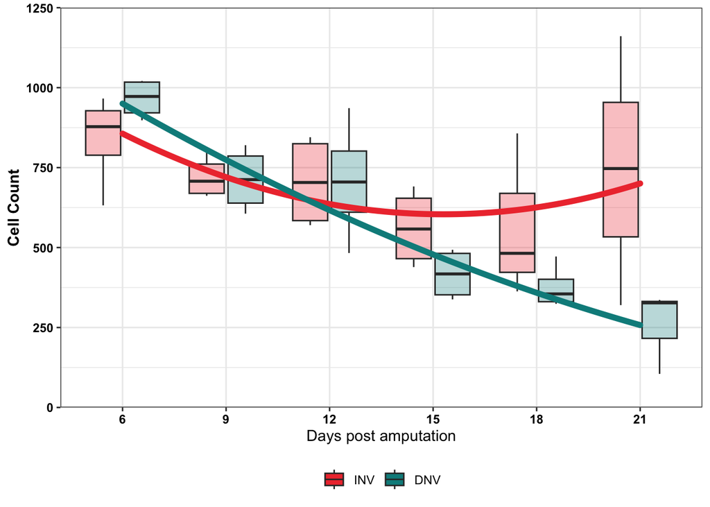

```r
ggplot() +
  geom_boxplot(data = totals,
               aes(x = factor(as.numeric(Timepoint),
                              levels = c(6,9,12,15,18,21)),
                   y = total_cells,
                   fill = factor(Innervation,
                                 levels = c("Innervated",
                                            "Denervated"),
                                 labels = c("INV", "DNV"))),
               alpha = 0.3,
               show.legend = T,
               outlier.alpha = 1) +
  geom_smooth(data = totals %>% filter(Innervation == "Innervated"),
              se = F,
              span = 10,
              aes(x = as.numeric(factor(as.numeric(Timepoint)+1,
                              levels = c(7,10,13,16,19,22))),
                  y = total_cells),
              color = "brown2",
              lineend = "round",
              linewidth = 2,
              show.legend = F) +
  geom_smooth(data = totals %>% filter(Innervation == "Denervated"),
              se = F,
              span = 10,
              aes(x = as.numeric(factor(as.numeric(Timepoint)+1,
                              levels = c(7,10,13,16,19,22))),
                  y = total_cells),
              color = "darkcyan",
              lineend = "round",
              linewidth = 2,
              show.legend = F) +
  xlab("Days post amputation") +
  ylab("Cell Count") +
  theme_bw() +
  scale_fill_manual(values = c("brown2", "darkcyan"),
                    breaks = c("INV", "DNV"),
                    guide = guide_legend(override.aes = c(alpha = 1))) +
  theme(legend.title = element_blank(),
        legend.position = "bottom",
        axis.text.x = element_text(face = "bold", colour = "black"),
        axis.text.y = element_text(face = "bold", colour = "black"),
        axis.title.y = element_text(face = "bold",
                                    colour = "black",
                                    family = "Arial")) +
  coord_cartesian(ylim = c(0, 1250)) +
  scale_y_continuous(expand = expansion(mult = c(0, 0)))
```

#### Cell count statistics

We show here that the total number of cells in the denervated digits over time can be fit to a linear curve indicating a downward trend. We show similarly that in innervated digits, a linear curve is not well fitted, represented by a very low R-squared. While not shown here, we found that the total number of cells in the innervated digits is best fit by a second-degree polynomial curve, representing the observed rebound in cell numbers.

```r
totals.sorted <- totals %>% arrange(Timepoint)
```

```r
inv.lm.linear <- lm(total_cells ~ Timepoint,
                    data = totals.sorted %>% filter(Innervation == "Innervated"))
summary(inv.lm.linear)
```

```
##
## Call:
## lm(formula = total_cells ~ Timepoint, data = totals.sorted %>%
##     filter(Innervation == "Innervated"))
##
## Residuals:
##     Min      1Q  Median      3Q     Max
## -422.67 -109.25    3.42  107.37  418.33
##
## Coefficients:
##             Estimate Std. Error t value Pr(>|t|)
## (Intercept)   705.50     102.81   6.862 3.82e-06 ***
## Timepoint15  -144.00     145.40  -0.990    0.337
## Timepoint18  -138.17     157.05  -0.880    0.392
## Timepoint21    37.17     157.05   0.237    0.816
## Timepoint6    133.00     145.40   0.915    0.374
## Timepoint9     17.50     145.40   0.120    0.906
## ---
## Signif. codes:  0 '***' 0.001 '**' 0.01 '*' 0.05 '.' 0.1 ' ' 1
##
## Residual standard error: 205.6 on 16 degrees of freedom
## Multiple R-squared:  0.2393, Adjusted R-squared:  0.00162
## F-statistic: 1.007 on 5 and 16 DF,  p-value: 0.4453
```

```r
dnv.lm.linear <- lm(total_cells ~ Timepoint,
             data = totals.sorted %>% filter(Innervation == "Denervated"))
summary(dnv.lm.linear)
```

```
##
## Call:
## lm(formula = total_cells ~ Timepoint, data = totals.sorted %>%
##     filter(Innervation == "Denervated"))
##
## Residuals:
##     Min      1Q  Median      3Q     Max
## -224.25  -61.12    0.50   66.62  228.75
##
## Coefficients:
##             Estimate Std. Error t value Pr(>|t|)
## (Intercept)   707.25      56.57  12.502 5.36e-10 ***
## Timepoint15  -290.75      80.00  -3.634 0.002050 **
## Timepoint18  -330.75      80.00  -4.134 0.000693 ***
## Timepoint21  -451.25      86.41  -5.222 6.90e-05 ***
## Timepoint6    258.75      80.00   3.234 0.004874 **
## Timepoint9      5.50      80.00   0.069 0.945992
## ---
## Signif. codes:  0 '***' 0.001 '**' 0.01 '*' 0.05 '.' 0.1 ' ' 1
##
## Residual standard error: 113.1 on 17 degrees of freedom
## Multiple R-squared:  0.8583, Adjusted R-squared:  0.8166
## F-statistic: 20.59 on 5 and 17 DF,  p-value: 1.144e-06
```

### Cell cycle state

Next, we sought to more closely resolve the cell cycle stage 15dpa innervated and denervated digit blastemas occupy. This was done by application of several immunofluorescent markers for the different cell cycle stages; distinct combinations of these markers indicate a cell’s current stage.

#### Preparing data

```r
results.path <- "../knitData/mesenchyme"
files <- Sys.glob( file.path( results.path, "*.xlsx" ) )

cc.data <- data.frame()
for(file in files){
  baseFilename <- basename( file_path_sans_ext(file) )
  animal <- unlist( str_split( baseFilename, "_") )[[2]]
  condition <- unlist( str_split( baseFilename, "_") )[[3]]

  df <- read.xlsx(file, sheetName = "Sheet2")
  colnames(df) <- c("Identity", "Count")

  total_cells = colSums(df %>% select(Count))
  df <- df %>%
    mutate(Animal = animal,
           Condition = condition,
           cellNum = total_cells)

  cc.data <- rbind(cc.data, df)
}
```

```r
# Categorizing cells based on their combinations of markers
g0 <- c("pH-,mC-,mA-,Ed-")
g1 <- c("pH-,mC+,mA-,Ed-")
s <- c("pH-,mC-,mA+,Ed+", "pH-,mC+,mA-,Ed+",
       "pH-,mC-,mA-,Ed+", "pH-,mC+,mA+,Ed+",
       "pH-,mC+,mA+,Ed-")
g2 <- c("pH-,mC-,mA+,Ed-")
m <- c("pH+,mC-,mA+,Ed-", "pH+,mC+,mA+,Ed-",
       "pH+,mC+,mA-,Ed-", "pH+,mC-,mA-,Ed-")

chart.data <- cc.data %>%
  mutate(new.ident = (case_when(Identity %in% g1 ~ "G1",
                                Identity %in% s ~ "S",
                                Identity %in% g2 ~ "G2",
                                Identity %in% m ~ "M",
                                Identity %in% g0 ~ "G0")),
         Condition = (case_when(Condition == "Inv" ~ "INV",
                                TRUE ~ "DNV"))) %>%
  filter(!is.na(new.ident)) %>%
  select(3, 4, 6, 2, 5) %>%
  group_by(Animal, Condition, new.ident, cellNum) %>%
  summarise(Total = sum(Count)) %>%
  select(Animal, Condition, new.ident, Total, cellNum)
```

```r
total.cells <- chart.data %>%
  group_by(Condition) %>%
  summarise(total_cells = sum(cellNum))
```

```r
merged <- left_join(chart.data,
                    total.cells,
                    by = c("Condition")) %>%
  mutate(prop = round((Total/total_cells)*100, 3)) %>%
  select(Animal, Condition, new.ident, prop) %>%
  `colnames<-`(c("Animal", "Condition", "Identity", "Proportion"))
```

```r
chart.data <- chart.data %>%
  mutate(total_cells = case_when(Condition == "INV" ~ 2500,
                                 Condition == "DNV" ~ 1950)) %>%
  group_by(Condition, new.ident, total_cells) %>%
  summarize(cell_total = sum(Total)) %>%
  mutate(prop = round((cell_total/total_cells)*100, 2))
```

| Condition | new.ident | total_cells | cell_total | prop |
| --- | --- | --- | --- | --- |
| DNV | G0 | 1950 | 242 | 12.41 |
| DNV | G1 | 1950 | 1472 | 75.49 |
| DNV | G2 | 1950 | 27 | 1.38 |
| DNV | M | 1950 | 6 | 0.31 |
| DNV | S | 1950 | 203 | 10.41 |
| INV | G0 | 2500 | 335 | 13.40 |

#### Plotting

In agreement with earlier analyses, we see that denervated blastemas show more cells arrested in G1 that do not progress to S phase.

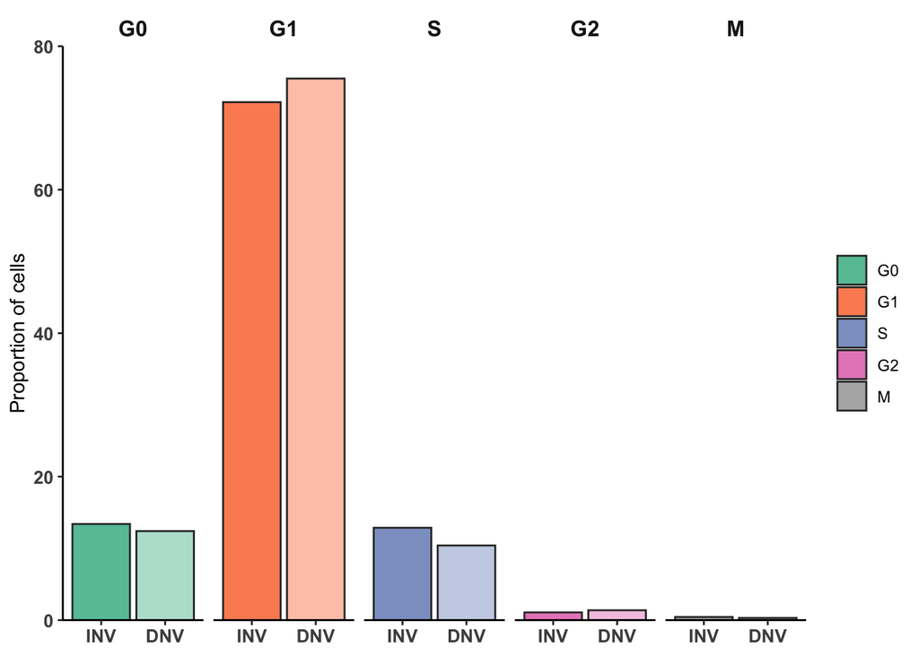

```r
ggplot(chart.data,
       aes(fill = factor(new.ident,
                         levels = c("G0", "G1", "S", "G2", "M")),
           x = factor(Condition, levels = c("INV", "DNV")),
           y = prop,
           alpha = factor(Condition, levels = c("INV", "DNV")) )) +
  geom_col(position = "identity",
           color = "gray20",
           linewidth = 0.5) +
  facet_grid(~factor(new.ident,
                     levels = c("G0", "G1", "S", "G2", "M") )) +
  theme_classic() +
  scale_y_continuous(expand = c(0, 0)) +
  scale_alpha_manual(values = c(1, 0.5)) +
  guides(alpha = "none") +
  coord_cartesian(ylim = c(0,80)) +
  ylab("Proportion of cells") +
  xlab(NULL) +
  scale_fill_manual(values = c("#66C2A5", "#FC8D62", "#8DA0CB", "#E78AC3", "#B3B3B3")) +
  theme(axis.text.x = element_text(face = "bold", family = "Arial", size = 10),
        axis.text.y = element_text(face = "bold", family = "Arial", size = 10),
        legend.title = element_blank(),
        strip.background = element_blank(),
        strip.text = element_text(size = 12, face = "bold", family = "Arial"),
        strip.placement = "bottom")
```

#### Stats

We aim to determine that there is a significant difference in the proportion of cells occupying each stage between innervated and denervated limbs. To that end, we performed chi-square tests for difference of proportions between innervated and denervated tissues at each stage. G0 shows no significant difference.

```r
G0.mat <- matrix(c(335, 2165,
                   242, 1708),
                 nrow = 2, ncol = 2,
                 byrow = T)
colnames(G0.mat) <- c("yes", "no")
rownames(G0.mat) <- c("INV", "DNV")
prop.test(G0.mat)
```

```
##
##  2-sample test for equality of proportions with continuity correction
##
## data:  G0.mat
## X-squared = 0.86527, df = 1, p-value = 0.3523
## alternative hypothesis: two.sided
## 95 percent confidence interval:
##  -0.01036933  0.03016420
## sample estimates:
##    prop 1    prop 2
## 0.1340000 0.1241026
```

As expected, there is a significantly higher proportion of denervated blastema cells in G1 than in innervated blastemas.

```r
G1.mat <- matrix(c(1805, 695,
                   1472, 478),
                 nrow = 2, ncol = 2,
                 byrow = T)
colnames(G1.mat) <- c("yes", "no")
rownames(G1.mat) <- c("INV", "DNV")
prop.test(G1.mat)
```

```
##
##  2-sample test for equality of proportions with continuity correction
##
## data:  G1.mat
## X-squared = 5.9301, df = 1, p-value = 0.01488
## alternative hypothesis: two.sided
## 95 percent confidence interval:
##  -0.059269341 -0.006474249
## sample estimates:
##    prop 1    prop 2
## 0.7220000 0.7548718
```

There is a significantly lower proportion of denervated blastema cells in S phase than in innervated blastemas, as these cells instead arrest in G1.

```r
S.mat <- matrix(c(322, 2178,
                   203, 1747),
                nrow = 2, ncol = 2,
                byrow = T)
colnames(S.mat) <- c("yes", "no")
rownames(S.mat) <- c("INV", "DNV")
prop.test(S.mat)
```

```
##
##  2-sample test for equality of proportions with continuity correction
##
## data:  S.mat
## X-squared = 6.1864, df = 1, p-value = 0.01287
## alternative hypothesis: two.sided
## 95 percent confidence interval:
##  0.005369051 0.044025820
## sample estimates:
##    prop 1    prop 2
## 0.1288000 0.1041026
```

There is no significant difference in the proportion of cells between innervated and denervated samples that occupy the G2 or M states.

```r
G2.mat <- matrix(c(27, 2473,
                   27, 1923),
                 nrow = 2, ncol = 2,
                 byrow = T)
colnames(G2.mat) <- c("yes", "no")
rownames(G2.mat) <- c("INV", "DNV")
prop.test(G2.mat)
```

```
##
##  2-sample test for equality of proportions with continuity correction
##
## data:  G2.mat
## X-squared = 0.61291, df = 1, p-value = 0.4337
## alternative hypothesis: two.sided
## 95 percent confidence interval:
##  -0.010083964  0.003991657
## sample estimates:
##     prop 1     prop 2
## 0.01080000 0.01384615
```

```r
M.mat <- matrix(c(11, 2489,
                  6, 1944),
                nrow = 2, ncol = 2,
                byrow = T)
colnames(M.mat) <- c("yes", "no")
rownames(M.mat) <- c("INV", "DNV")
prop.test(M.mat)
```

```
##
##  2-sample test for equality of proportions with continuity correction
##
## data:  M.mat
## X-squared = 0.21622, df = 1, p-value = 0.6419
## alternative hypothesis: two.sided
## 95 percent confidence interval:
##  -0.002707413  0.005353566
## sample estimates:
##      prop 1      prop 2
## 0.004400000 0.003076923
```

### APOEB

```r
results.path <- "../knitData/apoeb"
files <- Sys.glob( file.path( results.path, "G*.xlsx" ) )
apoeb.data <- data.frame()

# A separate characterization for autofluorescent blood cells was done
# in order to remove them from the analysis.
RBCs <- read.xlsx("../knitData/thresholds_and_RBCs.xlsx",
                  sheetIndex = 1) %>%
  pivot_longer(.,3:14) %>%
  select(1, 2, 4) %>%
  drop_na() %>%
  select(1,3) %>%
  `colnames<-`(c("Sample", "RBC_ID")) %>%
  separate_wider_delim(., 1, delim = "_", names_sep = "_") %>%
  `colnames<-`(c("Replicate", "Condition", "RBC_ID")) %>%
  mutate(Replicate = paste0("A",Replicate),
         Condition = str_to_upper(Condition)) %>%
  mutate(RBC_ID = as.character(RBC_ID))

for(file in files){
  baseFilename <- basename( file_path_sans_ext(file) )
  replicate <- unlist( str_split( baseFilename, "_") )[[2]]
  condition <- unlist( str_split( baseFilename, "_") )[[3]]

  df <- read.xlsx(file, sheetIndex = 1) %>%
    select(1, 2)
  num_cells <- nrow(df)
  colnames(df) <- c("Cell_ID", "Mean_Intensity")
  df <- df %>%
    mutate(Replicate = replicate,
           Condition = str_to_upper(condition),
           total_cells = num_cells) %>%
    mutate(Cell_ID = gsub("Segment #","",Cell_ID),
           state = case_when(Mean_Intensity >= 6127.6875 ~ "positive",
                             TRUE ~ "negative")) %>%
    mutate(Cell_ID = gsub(" \\(nuclei\\)", "", Cell_ID)) %>%
    mutate(Cell_ID = gsub(" \\(Cellpose-based Segmenter\\)","",Cell_ID))

  rbc.data <- RBCs %>%
    filter(Replicate == replicate &
             Condition == str_to_upper(condition))

  df <- df %>%
    mutate(state = case_when(Cell_ID %in% RBCs$RBC_ID ~ "negative",
                             TRUE ~ state))

  apoeb.data <- rbind(apoeb.data, df)

}
```

```r
apoeb.data <- apoeb.data %>%
  select(-Mean_Intensity)
pos.data <- apoeb.data %>%
  filter(state == "positive") %>%
  group_by(Replicate, Condition, total_cells) %>%
  summarise(num_positive = n())
pos.data <- pos.data %>%
  mutate(pct.pos = (num_positive/total_cells)*100) %>%
  mutate(pct.pos = round(pct.pos, 2))
```

| Replicate | Condition | total_cells | num_positive | pct.pos |
| --- | --- | --- | --- | --- |
| A1 | DNV | 228 | 29 | 12.72 |
| A1 | INV | 501 | 23 | 4.59 |
| A2 | DNV | 382 | 180 | 47.12 |
| A2 | INV | 360 | 8 | 2.22 |
| A3 | DNV | 379 | 89 | 23.48 |
| A3 | INV | 335 | 41 | 12.24 |

#### Plotting

We see a higher proportion of APOEB+ cells in denervated digits than in innervated, indicating a higher volume of macrophages.

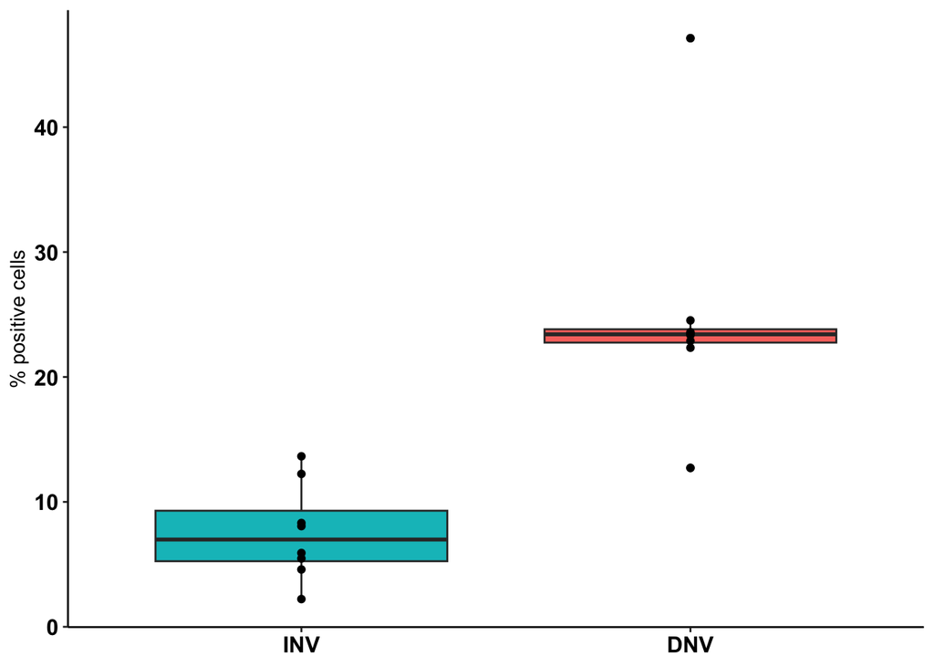

```r
ggplot(pos.data,
       aes(x = factor(Condition, levels = c("INV", "DNV")),
           y = pct.pos,
           fill = Condition)) +
  geom_boxplot() +
  geom_point() +
  guides(fill = "none") +
  theme_classic() +
  ylab("% positive cells") + xlab(NULL) +
  theme(axis.text.x = element_text(face = "bold", family = "Arial",
                                   color = "black", size = 12),
        axis.text.y = element_text(face = "bold", family = "Arial",
                                   color = "black", size = 12))
```

#### Stats

We confirm that there is a statistically significant difference in the proportion of myeloid cells in the denervated digit.

```r
wilcox.test(pos.data[pos.data$Condition == "INV",]$pct.pos,
            pos.data[pos.data$Condition == "DNV",]$pct.pos,
            p.adjust = "fdr")
```

```
##
##  Wilcoxon rank sum exact test
##
## data:  pos.data[pos.data$Condition == "INV", ]$pct.pos and pos.data[pos.data$Condition == "DNV", ]$pct.pos
## W = 1, p-value = 0.0003108
## alternative hypothesis: true location shift is not equal to 0
```

## Figure 3

### Digit fidelity

#### Overall fidelity

The data here are a categorization of whether or not a digit amputated below the first joint regenerated the joint structure, based on an earlier observation that digit regeneration was far less successful than more proximal amputations such as an amputation at the wrist.

```r
fidelity.summary <- read.xlsx("../knitData/Jackson_digits_cleaned.xlsx",
                              sheetIndex = 1) %>%
  drop_na() %>%
  mutate(Digit_Num = case_when(Digit_Num == 1 ~ "I",
                               Digit_Num == 2 ~ "II",
                               Digit_Num == 3 ~ "III",
                               Digit_Num == 4 ~ "IV"))
```

|  | Amp_plane | Digit_Num | Num_regen | Total | pct_regen |
| --- | --- | --- | --- | --- | --- |
| 1 | Digit | I | 14 | 25 | 56 |
| 2 | Digit | II | 25 | 25 | 100 |
| 3 | Digit | III | 2 | 25 | 8 |
| 4 | Digit | IV | 6 | 25 | 24 |
| 5 | Wrist | I | 24 | 25 | 96 |
| 6 | Wrist | II | 25 | 25 | 100 |

This chart confirms that digits are far less likely to regenerate the distal-most joint following amputation through the proximal or intermediate phalanx when compared to a more proximal amputation through the wrist. Further, there is considerable variability in the ability of individual digits to regenerate their distal-most joint, with digit II exhibiting the greatest regenerative fidelity.

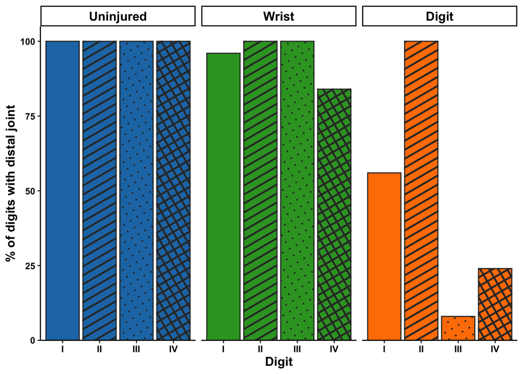

```r
ggplot(fidelity.summary,
       aes(x = Digit_Num,
           y = pct_regen,
           fill = factor(Amp_plane,
                         levels = c("Uninjured", "Wrist", "Digit")),
           pattern = Digit_Num)) +
  geom_col_pattern(color = "gray20", pattern_density = 0.1) +
  facet_grid(cols = vars(factor(Amp_plane,
                                levels = c("Uninjured", "Wrist", "Digit")))) +
  xlab("Digit") +
  ylab("% of digits with distal joint") +
  scale_y_continuous(expand = expansion(mult = c(0, 0.05))) +
  scale_fill_manual(values = c("#1F78B4", "#33A02C", "#FF7F00")) +
  scale_pattern_manual(values = c("none", "stripe", "pch", "crosshatch")) +
  guides(fill = "none", pattern = "none") +
  theme_classic() +
  theme(axis.text = element_text(face = "bold", color = "black",
                                   family = "Arial"),
        strip.text.x = element_text(face = "bold", color= "black",
                                    family = "Arial", size = 12),
        axis.title.x = element_text(color = "black", face = "bold",
                                    family = "Arial", size = 12),
        axis.title.y = element_text(color = "black", family = "Arial",
                                    size = 12, face = "bold"))
```

We performed tests of equal proportions in order to explore whether there are inter-digital differences in the regenerative fidelity of distal-most joints.

We see that there is no difference between digits in the uninjured limb.

```r
uninjured <- matrix(c(22,0,
                      22,0,
                      23,0,
                      22,0),
                    nrow = 4, ncol = 2,
                    byrow = T)
colnames(uninjured) <- c("regen", "not")
rownames(uninjured) <- c("D1", "D2", "D3", "D4")
prop.test(uninjured)
```

```
##
##  4-sample test for equality of proportions without continuity correction
##
## data:  uninjured
## X-squared = NaN, df = 3, p-value = NA
## alternative hypothesis: two.sided
## sample estimates:
## prop 1 prop 2 prop 3 prop 4
##      1      1      1      1
```

When examining wrist amputations, although the initial test across groups suggests a difference in regenerative fidelity, a pairwise test indicates no such significant difference.

```r
wrist <- matrix(c(24,1,
                  25,0,
                  25,0,
                  21,4),
                nrow = 4, ncol = 2,
                byrow = T)
colnames(wrist) <- c("regen", "not")
rownames(wrist) <- c("D1", "D2", "D3", "D4")
prop.test(wrist)
```

```
##
##  4-sample test for equality of proportions without continuity correction
##
## data:  wrist
## X-squared = 9.0526, df = 3, p-value = 0.0286
## alternative hypothesis: two.sided
## sample estimates:
## prop 1 prop 2 prop 3 prop 4
##   0.96   1.00   1.00   0.84
```

```r
pairwise.prop.test(wrist)
```

```
##
##  Pairwise comparisons using Pairwise comparison of proportions
##
## data:  wrist
##
##    D1   D2   D3
## D2 1.00 -    -
## D3 1.00 -    -
## D4 1.00 0.59 0.59
##
## P value adjustment method: holm
```

We see that there is a considerable inter-digital difference in regenerative fidelity when considering digit amputations.

```r
digit <- matrix(c(14,11,
                  25,0,
                  2,23,
                  6,19),
                nrow = 4, ncol = 2,
                byrow = T)
colnames(digit) <- c("regen", "not")
rownames(digit) <- c("D1", "D2", "D3", "D4")
prop.test(digit)
```

```
##
##  4-sample test for equality of proportions without continuity correction
##
## data:  digit
## X-squared = 49.578, df = 3, p-value = 9.823e-11
## alternative hypothesis: two.sided
## sample estimates:
## prop 1 prop 2 prop 3 prop 4
##   0.56   1.00   0.08   0.24
```

```r
pairwise.prop.test(digit)
```

```
##
##  Pairwise comparisons using Pairwise comparison of proportions
##
## data:  digit
##
##    D1     D2      D3
## D2 0.0026 -       -
## D3 0.0026 2.6e-09 -
## D4 0.0866 7.8e-07 0.2472
##
## P value adjustment method: holm
```

#### Joint gene expression

Given that digits exhibited considerable variability in their ability to form the distal joint following amputation, we were next interested in examining whether these digits express the genes *Gdf5* and *Noggin*, both important in proper joint formation. Amputated animals were examined at 20 and 30dpa for expression of both of these genes using whole-mount FISH.

```r
gdf5.data <- read.xlsx("../knitData/Jackson_digits_cleaned.xlsx",
                       sheetIndex = 2) %>%
  mutate(Digit = case_when(Digit == 1 ~ "I",
                               Digit == 2 ~ "II",
                               Digit == 3 ~ "III",
                               Digit == 4 ~ "IV"),
         DPA = case_when(DPA == 20 ~ "20 dpa",
                         DPA == 30 ~ "30 dpa"))
```

|  | Digit | DPA | num_with | total | pct_with |
| --- | --- | --- | --- | --- | --- |
| 1 | I | 20 dpa | 2 | 7 | 28.57143 |
| 2 | II | 20 dpa | 7 | 7 | 100.00000 |
| 3 | III | 20 dpa | 4 | 7 | 57.14286 |
| 4 | IV | 20 dpa | 5 | 7 | 71.42857 |
| 5 | I | 30 dpa | 4 | 7 | 57.14286 |
| 6 | II | 30 dpa | 6 | 7 | 85.71429 |

We see that, similarly to the formation of a joint as a whole, there is correspondent variability in each of the digits in their expression of joint-forming genes.

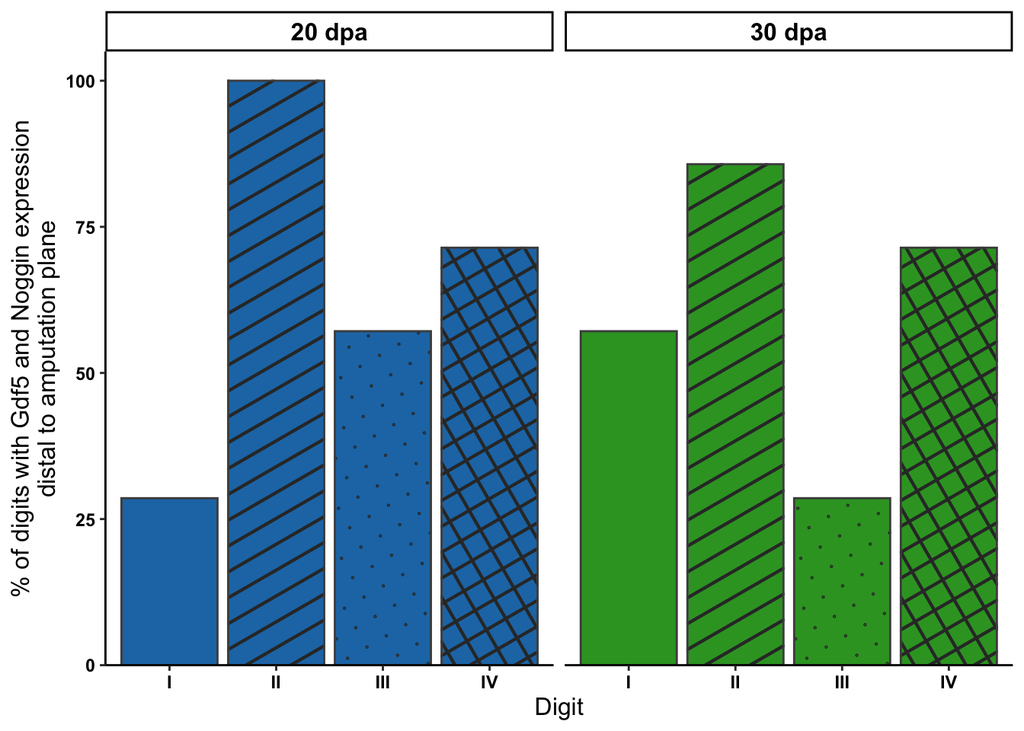

```r
ggplot(gdf5.data,
       aes(x = Digit,
           y = pct_with,
           fill = factor(DPA,
                         levels = c("20 dpa", "30 dpa")),
           pattern = Digit)) +
  geom_col_pattern(color = "gray30", pattern_density = 0.05) +
  facet_grid(cols = vars(factor(DPA,
                                levels = c("20 dpa", "30 dpa")))) +
  guides(fill = "none", pattern = "none") +
  labs(y = str_wrap("% of digits with Gdf5 and Noggin expression distal to amputation plane",
                    width = 45)) +
  scale_y_continuous(expand = expansion(mult = c(0, 0.05))) +
  scale_fill_manual(values = c("#1F78B4", "#33A02C")) +
  scale_pattern_manual(values = c("none", "stripe", "pch", "crosshatch")) +
  theme_classic() +
  theme(axis.text = element_text(face = "bold", color = "black",
                                   family = "Arial"),
        strip.text.x = element_text(face = "bold", color= "black",
                                    family = "Arial", size = 12),
        axis.title.x = element_text(color = "black",
                                    family = "Arial", size = 12),
        axis.title.y = element_text(color = "black", family = "Arial",
                                    size = 12))
```

We wished to compare each digit to determine if there is a significant difference in the proportion of digits which regenerated their distal-most joints.

At 20dpa, there is an overall significant difference, although this is lost in the pairwise test.

```r
dpa.20 <- matrix(c(2,5,
                   7,0,
                   4,3,
                   5,2),
                 nrow = 4, ncol = 2,
                 byrow = T)
colnames(dpa.20) <- c("with", "without")
rownames(dpa.20) <- c("D1", "D2", "D3", "D4")
prop.test(dpa.20)
```

```
##
##  4-sample test for equality of proportions without continuity correction
##
## data:  dpa.20
## X-squared = 8.0889, df = 3, p-value = 0.04421
## alternative hypothesis: two.sided
## sample estimates:
##    prop 1    prop 2    prop 3    prop 4
## 0.2857143 1.0000000 0.5714286 0.7142857
```

```r
pairwise.prop.test(dpa.20)
```

```
##
##  Pairwise comparisons using Pairwise comparison of proportions
##
## data:  dpa.20
##
##    D1   D2   D3
## D2 0.15 -    -
## D3 1.00 0.96 -
## D4 1.00 1.00 1.00
##
## P value adjustment method: holm
```

At 30dpa we see no significant difference among groups in the expression of these genes.

```r
dpa.30 <- matrix(c(4,3,
                   6,1,
                   2,5,
                   5,2),
                 nrow = 4, ncol = 2,
                 byrow = T)
colnames(dpa.30) <- c("with", "without")
rownames(dpa.30) <- c("D1", "D2", "D3", "D4")
prop.test(dpa.30)
```

```
##
##  4-sample test for equality of proportions without continuity correction
##
## data:  dpa.30
## X-squared = 5.2406, df = 3, p-value = 0.155
## alternative hypothesis: two.sided
## sample estimates:
##    prop 1    prop 2    prop 3    prop 4
## 0.5714286 0.8571429 0.2857143 0.7142857
```

### Neurite volume & EdU positive

We were interested in exploring whether the lack of joint reformation following injury may be due to interdigital differences in innervation or cell proliferation.

#### Neurite volume

First, we examine neurite volume in each digit normalized to the total number of cells present in the digit.

```r
volumes <- read.xlsx("../knitData/summary_new.xlsx",
                     sheetIndex = 1) %>%
  mutate(Digit = case_when(Digit == 1 ~ "I",
                           Digit == 2 ~ "II",
                           Digit == 3 ~ "III",
                           Digit == 4 ~ "IV")) %>%
  mutate(normalized_volume = Volume/Cells)
```

|  | Digit | Replicate | Volume | Cells | normalized_volume |
| --- | --- | --- | --- | --- | --- |
| 1 | I | 1 | 14491.617 | 1306 | 11.096185 |
| 2 | I | 2 | 8139.997 | 1368 | 5.950290 |
| 3 | I | 3 | 9132.634 | 1186 | 7.700366 |
| 4 | I | 4 | 5615.163 | 961 | 5.843041 |
| 5 | I | 6 | 2792.313 | 1129 | 2.473262 |
| 6 | I | 7 | 1441.333 | 1191 | 1.210187 |

Visually there appears to be no difference in digit innervation.

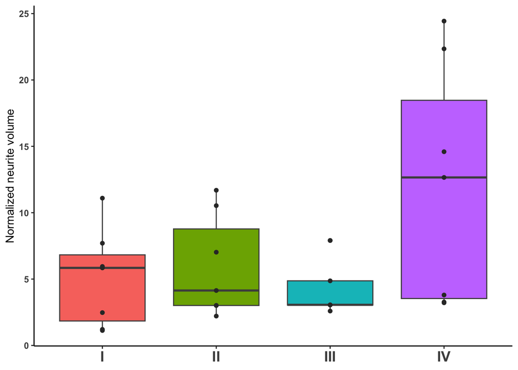

```r
ggplot(volumes,
       aes(x = Digit,
           y = normalized_volume,
           fill = Digit)) +
  geom_boxplot(color = "gray30") +
  geom_point(color = "gray20") +
  theme_classic() +
  ylab("Normalized neurite volume") +
  xlab(NULL) +
  guides(fill = "none") +
  theme(axis.text.x = element_text(face = "bold", family = "Arial",
                                   size = 14),
        axis.text.y = element_text(face = "bold", family = "Arial"))
```

#### EdU positive

Next we examined the proportion of cells in each digit that were actively cycling.

```r
results.path <- "../knitData/results 2"
files <- Sys.glob( file.path( results.path, "D*.xlsx" ) )
edu.data <- data.frame()

for(file in files){
  baseFilename <- basename( file_path_sans_ext(file) )
  replicate <- unlist( str_split( baseFilename, "_") )[[2]]
  digit <- unlist( str_split( baseFilename, "_") )[[1]]

  df <- read.xlsx(file, sheetIndex = 1) %>%
    select(3)
  num_cells <- nrow(df)
  colnames(df) <- c("Mean_Intensity")
  df <- df %>%
    mutate(Replicate = replicate,
           Digit = digit,
           total_cells = num_cells)

  edu.data <- rbind(edu.data, df)

}

edu.data <- edu.data %>%
  mutate(state = case_when(Mean_Intensity >= 1750 ~ "positive",
                           TRUE ~ "negative"))
```

```r
chart.data.pos <- edu.data %>%
  filter(state == "positive") %>%
  group_by(Replicate, Digit, total_cells) %>%
  summarise(pos_cells = n()) %>%
  mutate(pct.pos = (pos_cells/total_cells)*100,
         Digit = gsub("D","",Digit)) %>%
  select(1,2,5)

chart.data.neg <- edu.data %>%
  filter(state == "negative") %>%
  group_by(Replicate, Digit, total_cells) %>%
  summarise(negative_cells = n()) %>%
  mutate(pct.neg = (negative_cells/total_cells)*100,
         Digit = gsub("D","",Digit)) %>%
  select(1,2,5)

chart.data.pos.tests <- chart.data.pos[-c(20,21),]
chart.data <- chart.data.pos.tests
```

There again appears to be no difference between digits in the proportion of cycling cells.

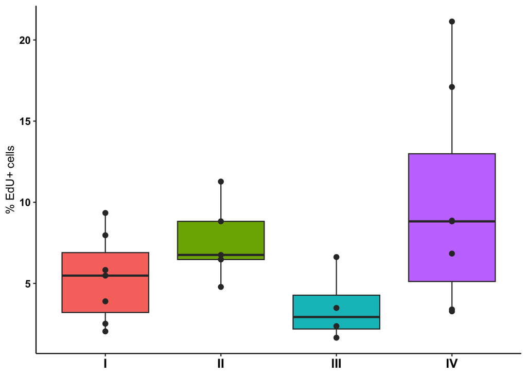

```r
ggplot(chart.data.pos.tests,
       aes(x = Digit,
           y = pct.pos,
           fill = Digit)) +
  geom_boxplot() +
  geom_point(size = 2, color = "gray20") +
  ylab("% EdU+ cells") +
  xlab(NULL) +
  guides(fill = "none") +
  theme_classic() +
  theme(axis.text.x = element_text(face = "bold", family = "Arial",
                                   color = "black", size = 12),
        axis.text.y = element_text(face = "bold", family = "Arial",
                                   color = "black", size = 10))
```

#### Stats

```r
neurite.mergeData <- edu.data %>%
  select(Replicate, Digit, total_cells) %>%
  unique() %>%
  mutate(Digit = gsub("D","", Digit)) %>%
  left_join(.,chart.data, by = c("Replicate", "Digit"))

neurite.mergeData <- neurite.mergeData %>%
  select(2,1,3,4) %>%
  mutate(dig_rep = paste0(Digit,"_",Replicate))
```

```r
volumes <- volumes %>%
  mutate(dig_rep = paste0(Digit,"_",Replicate))
```

```r
merged <- left_join(neurite.mergeData, volumes, by = "dig_rep") %>%
  select(dig_rep, total_cells, normalized_volume, pct.pos) %>%
  separate_wider_delim(.,"dig_rep", delim = "_", names_sep = "-")
colnames(merged) <- c("Digit", "Replicate", "Cells", "norm_neuriteVolume", "pct.pos")
merged <- merged %>%
  filter(!(Digit == "II" & Replicate == 7)) %>%
  drop_na()
```

A Kruskal-Wallis test on the proportion of EdU positive cells by digit indicates no significant difference between digits.

```r
# EdU positive
kruskal.test(pct.pos ~ Digit, merged)
```

```
##
##  Kruskal-Wallis rank sum test
##
## data:  pct.pos by Digit
## Kruskal-Wallis chi-squared = 6.1503, df = 3, p-value = 0.1045
```

Similarly, a Kruskal-Wallis test for neurite volume indicates no significant difference between digits in the relative level of innervation. Together, these two points suggest that differences in innervation or cell cycling do not contribute to digits’ variability in joint regeneration.

```r
# Neurite volume
kruskal.test(norm_neuriteVolume ~ Digit, merged)
```

```
##
##  Kruskal-Wallis rank sum test
##
## data:  norm_neuriteVolume by Digit
## Kruskal-Wallis chi-squared = 3.9267, df = 3, p-value = 0.2695
```

## Figure 4

#### Hedgehog signaling

The Hedgehog signaling pathway is important for correct joint morphology. We sought to examine the role of Hedgehog signaling in digit regeneration and its role in joint reformation. To that end, animals were amputated at the wrist or at the digit level and treated with a DMSO control, cyclopamine (a Hedgehog inhibitor), and smoothened agonist (SAG; a Hedgehog activator), then assessed for distal joint formation.

```r
hedgehog.data <- read.xlsx("../knitData/Jackson_digits_cleaned.xlsx",
                           sheetIndex = 3) %>%
  mutate(Digit_num = case_when(Digit_num == 1 ~ "I",
                               Digit_num == 2 ~ "II",
                               Digit_num == 3 ~ "III",
                               Digit_num == 4 ~ "IV"),
         grid = case_when(Treatment == "Control" ~ paste0("Control ", Amp_plane),
                          Treatment == "Cyclo" ~ "Digit + Cyclopamine",
                          Treatment == "SAG" ~ "Digit + SAG"))
```

|  | Amp_plane | Digit_num | Treatment | num_regen | total | pct_regen | grid |
| --- | --- | --- | --- | --- | --- | --- | --- |
| 1 | Wrist | I | Control | 19 | 19 | 100.00000 | Control Wrist |
| 2 | Wrist | II | Control | 19 | 19 | 100.00000 | Control Wrist |
| 3 | Wrist | III | Control | 16 | 19 | 84.21053 | Control Wrist |
| 4 | Wrist | IV | Control | 18 | 19 | 94.73684 | Control Wrist |
| 5 | Digit | I | Control | 7 | 19 | 36.84211 | Control Digit |
| 6 | Digit | II | Control | 17 | 19 | 89.47368 | Control Digit |

We see that, as noted before, digit amputations exhibit overall lower fidelity in joint regeneration compared to more proximal amputations, and that this fidelity varies across digits. Further, none of the digits in which the Hedgehog signaling pathway was interrupted via cyclopamine treatment regenerated their joints. However, activation of Hedgehog signaling with SAG was not itself sufficient to promote regenerative fidelity.

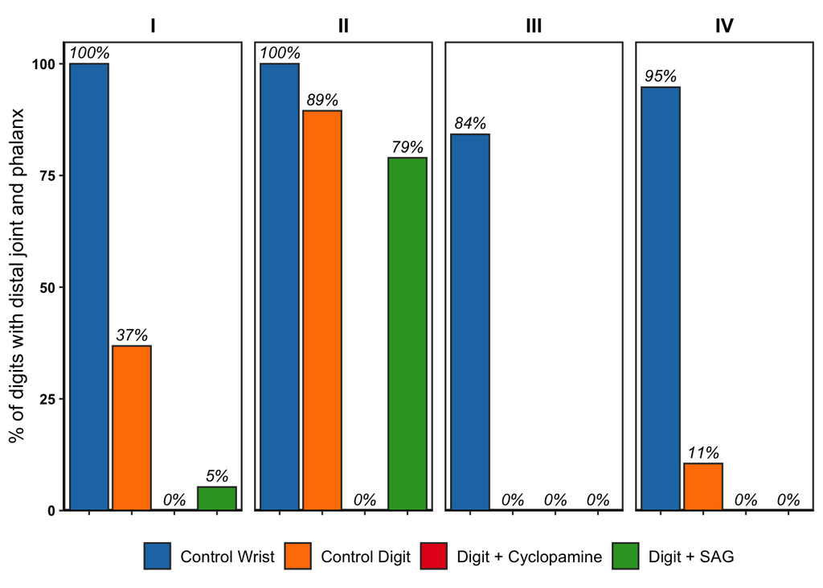

```r
ggplot(hedgehog.data,
       aes(x = factor(grid,
                      levels = c("Control Wrist",
                                 "Control Digit",
                                 "Digit + Cyclopamine",
                                 "Digit + SAG")),
           y = pct_regen,
           fill = factor(grid,
                         levels = c("Control Wrist",
                                    "Control Digit",
                                    "Digit + Cyclopamine",
                                    "Digit + SAG")))) +
  geom_col(color = "gray20") +
  geom_text(aes(label = paste0(round(pct_regen),"%")),
            vjust = -0.5,
            family = "Arial",
            fontface = "italic",
            color = "black",
            size = 3.5) +
  facet_grid(cols = vars(Digit_num)) +
  xlab(NULL) +
  ylab("% of digits with distal joint and phalanx") +
  scale_y_continuous(expand = expansion(mult = c(0, 0.05))) +
  scale_fill_manual(values = c("#1F78B4","#FF7F00", "#E31A1C", "#33A02C")) +
  theme_classic() +
  guides(title = "Treatment", position = "bottom") +
  theme(axis.text.x = element_blank(),
        axis.text.y = element_text(face = "bold",
                                   color = "black", family = "Arial"),
        strip.text.x = element_text(face = "bold",
                                    color= "black", family = "Arial", size = 12),
        axis.title.y = element_text(color = "black", family = "Arial", size = 12),
        legend.position = "bottom",
        legend.title = element_blank(),
        panel.spacing = unit(0.25, "cm"),
        panel.background = element_rect(color = "gray20", linewidth = 1),
        strip.background = element_blank(),
        legend.key = element_rect(color = "white"),
        legend.text = element_text(family = "Arial", color = "black", size = 10))
```

We wanted to test the difference in joint regeneration between groups by digit. Some tests fail given the overall lack of joint regeneration in several groups.

##### Digit I

```r
D1.mat <- matrix(c(19, 0,
                   7, 12,
                   0, 19,
                   1, 18), nrow = 4, ncol = 2, byrow = T)
colnames(D1.mat) <- c("regen", "not")
rownames(D1.mat) <- c("Wrist", "Digit", "Cyclo", "SAG")
prop.test(D1.mat)
```

```
##
##  4-sample test for equality of proportions without continuity correction
##
## data:  D1.mat
## X-squared = 52.562, df = 3, p-value = 2.273e-11
## alternative hypothesis: two.sided
## sample estimates:
##     prop 1     prop 2     prop 3     prop 4
## 1.00000000 0.36842105 0.00000000 0.05263158
```

```r
pairwise.prop.test(D1.mat)
```

```
##
##  Pairwise comparisons using Pairwise comparison of proportions
##
## data:  D1.mat
##
##       Wrist   Digit   Cyclo
## Digit 0.00049 -       -
## Cyclo 3.1e-08 0.03614 -
## SAG   1.7e-07 0.09328 1.00000
##
## P value adjustment method: holm
```

##### Digit II

```r
D2.mat <- matrix(c(19, 0,
                  17, 2,
                   0, 19,
                   15, 4), nrow = 4, ncol = 2, byrow = T)
colnames(D2.mat) <- c("regen", "not")
rownames(D2.mat) <- c("Wrist", "Digit", "Cyclo", "SAG")
prop.test(D2.mat)
```

```
##
##  4-sample test for equality of proportions without continuity correction
##
## data:  D2.mat
## X-squared = 53.587, df = 3, p-value = 1.374e-11
## alternative hypothesis: two.sided
## sample estimates:
##    prop 1    prop 2    prop 3    prop 4
## 1.0000000 0.8947368 0.0000000 0.7894737
```

```r
pairwise.prop.test(D2.mat)
```

```
##
##  Pairwise comparisons using Pairwise comparison of proportions
##
## data:  D2.mat
##
##       Wrist   Digit   Cyclo
## Digit 0.94    -       -
## Cyclo 3.1e-08 8.9e-07 -
## SAG   0.34    0.94    1.4e-05
##
## P value adjustment method: holm
```

##### Digit III

```r
D3.mat <- matrix(c(16, 3,
                   0, 19,
                   0, 19,
                   0, 19), nrow = 4, ncol = 2, byrow = T)
colnames(D3.mat) <- c("regen", "not")
rownames(D3.mat) <- c("Wrist", "Digit", "Cyclo", "SAG")
prop.test(D3.mat)
```

```
##
##  4-sample test for equality of proportions without continuity correction
##
## data:  D3.mat
## X-squared = 60.8, df = 3, p-value = 3.966e-13
## alternative hypothesis: two.sided
## sample estimates:
##    prop 1    prop 2    prop 3    prop 4
## 0.8421053 0.0000000 0.0000000 0.0000000
```

```r
pairwise.prop.test(D3.mat)
```

```
##
##  Pairwise comparisons using Pairwise comparison of proportions
##
## data:  D3.mat
##
##       Wrist   Digit Cyclo
## Digit 2.5e-06 -     -
## Cyclo 2.5e-06 -     -
## SAG   2.5e-06 -     -
##
## P value adjustment method: holm
```

##### Digit IV

```r
D4.mat <- matrix(c(18, 1,
                   2, 17,
                   0, 19,
                   0, 19), nrow = 4, ncol = 2, byrow = T)
colnames(D4.mat) <- c("regen", "not")
rownames(D4.mat) <- c("Wrist", "Digit", "Cyclo", "SAG")
prop.test(D4.mat)
```

```
##
##  4-sample test for equality of proportions without continuity correction
##
## data:  D4.mat
## X-squared = 61.886, df = 3, p-value = 2.324e-13
## alternative hypothesis: two.sided
## sample estimates:
##    prop 1    prop 2    prop 3    prop 4
## 0.9473684 0.1052632 0.0000000 0.0000000
```

```r
pairwise.prop.test(D4.mat)
```

```
##
##  Pairwise comparisons using Pairwise comparison of proportions
##
## data:  D4.mat
##
##       Wrist   Digit Cyclo
## Digit 3.3e-06 -     -
## Cyclo 1.7e-07 0.94  -
## SAG   1.7e-07 0.94  -
##
## P value adjustment method: holm
```

## Other

The main goals of this analysis were to explore whether there is a difference in relative regenerated lengths of each digit, and to consider if the regenerated tissue is a different length with or without a regenerated joint. Further, groups are included which are treated with SAG, a hedgehog agonist, and Cyclopamine, a hedgehog signaling inhibitor, to determine the role of hedgehog signaling in joint regeneration fidelity. These analyses were ultimately not included in the publication owing to the inability to meaningfully analyze the impact of joint regeneration on digit length.

Note that lot of data cleaning needs to be done to be able to use this data. These measurements were collected by two separate students in the lab and are processed independently, then combined.

### Overall digit length

#### Data cleaning

Preparing the first student’s data, first from the digits data and then appending the data collected from the wrist. The input data is in a messy wideform that needs cleaning up to be able to plot and run statistics.

```r
digits.1 <- read.xlsx("../knitData/Hedgehog_skeletal_measurements_1.xlsx",
                          sheetIndex = 1)[1:20,] %>%
  select(!c(4,6,7,9,11,13,16,18,19,21,23,25,28,30,31,33,35))
```

Digit data for student 1 prior to cleaning:

|  | Animal | Condition | DI_meta | DII_meta | DIII_Ph2 | DIV_meta | norm | Condition.1 | DI_meta.1 | DII_meta.1 | DIII_Ph2.1 | DIV_meta.1 | norm.1 | Condition.2 | DI_meta.2 | DII_meta.2 | DIII_Ph2.2 | DIV_meta.2 | norm.2 |
| --- | --- | --- | --- | --- | --- | --- | --- | --- | --- | --- | --- | --- | --- | --- | --- | --- | --- | --- | --- |
| 1 | 1 | Control | 0.962 | 1.743 | 1.144 | 1.096 | 1.868 | SAG | 0.936 | 1.560 | 1.000 | 1.093 | 1.912 | cyclopamine | 1.053 | 1.307 | 0.873 | 0.874 | 1.953 |
| 2 | 2 | Control | 1.152 | 1.758 | 1.148 | 1.164 | 1.896 | SAG | 1.185 | 2.010 | 1.201 | 1.253 | 2.130 | cyclopamine | 0.956 | 1.513 | 0.955 | 0.997 | 1.991 |
| 3 | 3 | Control | 1.111 | 1.967 | 1.172 | 1.242 | 2.137 | SAG | 0.876 | 1.658 | 1.116 | 1.044 | 1.953 | cyclopamine | 0.817 | 1.584 | 0.843 | 1.039 | 2.028 |
| 4 | 4 | Control | 1.370 | 1.963 | 1.310 | 1.285 | 2.090 | SAG | 1.152 | 1.812 | 1.298 | 1.408 | 2.096 | cyclopamine | 1.072 | 1.372 | 1.169 | 1.007 | 1.849 |
| 5 | 5 | Control | 1.085 | 1.897 | 1.094 | 1.056 | 2.110 | SAG | 1.074 | 1.892 | 1.246 | 1.124 | 2.031 | cyclopamine | 0.922 | 1.643 | 1.025 | 0.967 | 2.336 |
| 6 | 6 | Control | 1.000 | 1.575 | 1.113 | 1.091 | 1.970 | SAG | 1.086 | 1.616 | 1.210 | 1.078 | 1.800 | cyclopamine | 0.950 | 1.588 | 1.153 | 0.961 | 2.056 |

```r
# Manually inputting some missing values
digits.1[11,1] <- "11"
digits.1[11,2] <- "Control"
digits.1[20,8] <- "SAG"
digits.1[20,14] <- "cyclopamine"

digits.1.long <- digits.1 %>%
  select(1:7) %>%
  `colnames<-`(c("Animal", "Condition",
                 "DI", "DII", "DIII", "DIV", "Norm")) %>%
  rbind(., digits.1 %>% select(1, 8:13) %>%
          `colnames<-`(c("Animal", "Condition",
                         "DI", "DII", "DIII", "DIV", "Norm"))) %>%
  rbind(., digits.1 %>% select(1, 14:19) %>%
        `colnames<-`(c("Animal", "Condition",
                       "DI", "DII", "DIII", "DIV", "Norm")))
digits.1 <- digits.1.long
rm(digits.1.long)
```

Following cleaning:

|  | Animal | Condition | DI | DII | DIII | DIV | Norm |
| --- | --- | --- | --- | --- | --- | --- | --- |
| 1 | 1 | Control | 0.962 | 1.743 | 1.144 | 1.096 | 1.868 |
| 2 | 2 | Control | 1.152 | 1.758 | 1.148 | 1.164 | 1.896 |
| 3 | 3 | Control | 1.111 | 1.967 | 1.172 | 1.242 | 2.137 |
| 4 | 4 | Control | 1.370 | 1.963 | 1.310 | 1.285 | 2.090 |
| 5 | 5 | Control | 1.085 | 1.897 | 1.094 | 1.056 | 2.110 |
| 6 | 6 | Control | 1.000 | 1.575 | 1.113 | 1.091 | 1.970 |

```r
# Similar preparation for the wrist data
wrist.1 <- read.xlsx("../knitData/Hedgehog_skeletal_measurements_1.xlsx",
                     sheetIndex = 2)[1:20,1:12] %>%
  select(1:3,5,8,10,12)
```

Wrist data for student 1 prior to cleaning:

|  | Animal | Condition | DI_meta | DII_meta | DIII_Ph2 | DIV_meta | norm |
| --- | --- | --- | --- | --- | --- | --- | --- |
| 1 | 1 | Control | 1.408 | 2.135 | 1.002 | 1.326 | 1.700 |
| 2 | 2 | Control | 1.438 | 2.017 | 1.192 | 1.293 | 1.504 |
| 3 | 3 | Control | 1.564 | 2.262 | 0.987 | 1.445 | 1.864 |
| 4 | 4 | Control | 1.652 | 2.268 | 1.617 | 1.475 | 1.756 |
| 5 | 5 | Control | 1.543 | 2.348 | 1.529 | 1.346 | 1.839 |
| 6 | 6 | Control | 1.551 | 2.252 | 1.364 | 1.407 | 1.738 |

```r
wrist.1[11,1] <- "11"
wrist.1[11,2] <- "Control"
wrist.1 <- wrist.1 %>%
  `colnames<-`(c("Animal", "Condition", "DI", "DII", "DIII", "DIV", "Norm")) %>%
  mutate(Condition = "Wrist")

digits.1 <- rbind(digits.1, wrist.1)
digits.1 <- digits.1[-c(11,40,60,71),]
rm(wrist.1)
```

Final data for student 1, combining digit and wrist measurements:

|  | Animal | Condition | DI | DII | DIII | DIV | Norm |
| --- | --- | --- | --- | --- | --- | --- | --- |
| 1 | 1 | Control | 0.962 | 1.743 | 1.144 | 1.096 | 1.868 |
| 2 | 2 | Control | 1.152 | 1.758 | 1.148 | 1.164 | 1.896 |
| 3 | 3 | Control | 1.111 | 1.967 | 1.172 | 1.242 | 2.137 |
| 4 | 4 | Control | 1.370 | 1.963 | 1.310 | 1.285 | 2.090 |
| 5 | 5 | Control | 1.085 | 1.897 | 1.094 | 1.056 | 2.110 |
| 6 | 6 | Control | 1.000 | 1.575 | 1.113 | 1.091 | 1.970 |

Now preparing the second student’s data.

```r
digits.2 <- read.xlsx("../knitData/Hedgehog_skeletal_measurements_2.xlsx", sheetIndex = 1)[1:20,] %>%
  select(!c(4,6,7,9,11,13,16,18,19,21,23,25,28,30,31,33,35))
```

Student 2’s digit data prior to cleaning:

|  | Animal | Condition | DI_meta | DII_meta | DIII_P2 | DIV_meta | norm | Condition.1 | DI_meta.1 | DII_meta.1 | DIII_P2.1 | DIV_meta.1 | norm.1 | Condition.2 | DI_meta.2 | DII_meta.2 | DIII_P2.2 | DIV_meta.2 | norm.2 |
| --- | --- | --- | --- | --- | --- | --- | --- | --- | --- | --- | --- | --- | --- | --- | --- | --- | --- | --- | --- |
| 1 | 1 | Control | 0.874 | 1.713 | 1.183 | 1.046 | 1.809 | SAG | 0.863 | 1.574 | 1.009 | 1.100 | 1.945 | cyclopamine | 1.147 | 1.785 | 1.199 | 1.26 | 1.925 |
| 2 | 2 | Control | 1.118 | 1.743 | 1.194 | 1.091 | 1.854 | SAG | 1.224 | 1.998 | 1.157 | 1.178 | 2.070 | cyclopamine | 1.097 | 1.493 | 0.950 | 0.935 | 1.938 |
| 3 | 3 | Control | 1.058 | 1.911 | 1.102 | 1.195 | 2.158 | SAG | 0.899 | 1.687 | 1.178 | 1.013 | 1.968 | cyclopamine | 0.779 | 1.577 | 0.858 | 0.995 | 2.002 |
| 4 | 4 | Control | 1.401 | 2.030 | 1.232 | 1.215 | 2.045 | SAG | 1.110 | 1.786 | 1.266 | 1.329 | 2.026 | cyclopamine | 0.999 | 1.331 | 1.130 | 0.913 | 1.846 |
| 5 | 5 | Control | 1.018 | 1.855 | 1.058 | 0.980 | 2.097 | SAG | 1.079 | 1.907 | 1.262 | 1.066 | 1.977 | cyclopamine | 0.966 | 1.612 | 1.007 | 1.012 | 2.291 |
| 6 | 6 | Control | 0.984 | 1.554 | 1.031 | 1.020 | 1.970 | SAG | 1.075 | 1.714 | 1.240 | 1.117 | 1.844 | cyclopamine | 0.930 | 1.616 | 1.138 | 0.978 | 2.050 |

```r
digits.2[11,1] <- "11"
digits.2[11,2] <- "Control"
digits.2[20,8] <- "SAG"
digits.2[20,14] <- "cyclopamine"

digits.2.long <- digits.2 %>%
  select(1:7) %>%
  `colnames<-`(c("Animal", "Condition",
                 "DI", "DII", "DIII", "DIV", "Norm")) %>%
  rbind(., digits.2 %>% select(1, 8:13) %>%
          `colnames<-`(c("Animal", "Condition",
                         "DI", "DII", "DIII", "DIV", "Norm"))) %>%
  rbind(., digits.2 %>% select(1, 14:19) %>%
          `colnames<-`(c("Animal", "Condition",
                         "DI", "DII", "DIII", "DIV", "Norm")))
digits.2 <- digits.2.long
rm(digits.2.long)
```

After cleaning:

|  | Animal | Condition | DI | DII | DIII | DIV | Norm |
| --- | --- | --- | --- | --- | --- | --- | --- |
| 1 | 1 | Control | 0.874 | 1.713 | 1.183 | 1.046 | 1.809 |
| 2 | 2 | Control | 1.118 | 1.743 | 1.194 | 1.091 | 1.854 |
| 3 | 3 | Control | 1.058 | 1.911 | 1.102 | 1.195 | 2.158 |
| 4 | 4 | Control | 1.401 | 2.030 | 1.232 | 1.215 | 2.045 |
| 5 | 5 | Control | 1.018 | 1.855 | 1.058 | 0.98 | 2.097 |
| 6 | 6 | Control | 0.984 | 1.554 | 1.031 | 1.02 | 1.970 |

```r
wrist.2 <- read.xlsx("../knitData/Hedgehog_skeletal_measurements_2.xlsx",
                     sheetIndex = 2)[,1:12] %>%
  select(1:3,5,8,10,12)
```

Student 2’s wrist data prior to cleaning:

|  | Animal | Condition | DI_meta | DII_meta | DIII_P2 | DIV_meta | norm |
| --- | --- | --- | --- | --- | --- | --- | --- |
| 1 | 1 | Control | 1.452 | 2.114 | 1.489 | 1.276 | 1.784 |
| 2 | 2 | Control | 1.494 | 2.018 | 1.192 | 1.305 | 1.599 |
| 3 | 3 | Control | 1.507 | 2.289 | 0.976 | 1.483 | 1.862 |
| 4 | 4 | Control | 1.628 | 2.324 | 1.605 | 1.422 | 1.714 |
| 5 | 5 | Control | 1.543 | 2.280 | 1.549 | 1.361 | 1.809 |
| 6 | 6 | Control | 1.553 | 2.282 | 1.350 | 1.377 | 1.734 |

```r
wrist.2[11,1] <- "11"
wrist.2[11,2] <- "Control"
wrist.2 <- wrist.2 %>%
  `colnames<-`(c("Animal", "Condition", "DI", "DII", "DIII", "DIV", "Norm")) %>%
  mutate(Condition = "Wrist")

digits.2 <- rbind(digits.2, wrist.2)
digits.2 <- digits.2[-c(11,40,60,71),]
digits.2[45,6] <- NA
rm(wrist.2)
```

Final digit and wrist measurements for student 2:

|  | Animal | Condition | DI | DII | DIII | DIV | Norm |
| --- | --- | --- | --- | --- | --- | --- | --- |
| 1 | 1 | Control | 0.874 | 1.713 | 1.183 | 1.046 | 1.809 |
| 2 | 2 | Control | 1.118 | 1.743 | 1.194 | 1.091 | 1.854 |
| 3 | 3 | Control | 1.058 | 1.911 | 1.102 | 1.195 | 2.158 |
| 4 | 4 | Control | 1.401 | 2.030 | 1.232 | 1.215 | 2.045 |
| 5 | 5 | Control | 1.018 | 1.855 | 1.058 | 0.98 | 2.097 |
| 6 | 6 | Control | 0.984 | 1.554 | 1.031 | 1.02 | 1.970 |

Joining the two students’ data for plotting and statistics.

```r
# Averaging the students' measured original digit length for normalizing
merged <- full_join(digits.1, digits.2, by = c("Animal", "Condition")) %>%
  mutate(final.norm = (`Norm.x` + `Norm.y`)/2) %>%
  select(-c(`Norm.x`, `Norm.y`)) %>%
  # Also averaging measured digit lengths
  mutate(DI.avg = case_when(is.na(DI.x) | is.na(DI.y) ~ NA,
                            TRUE ~ (DI.x + DI.y)/2),
         DII.avg = case_when(is.na(DII.x) | is.na(DII.y) ~ NA,
                            TRUE ~ (DII.x + DII.y)/2),
         DIII.avg = case_when(is.na(DIII.x) | is.na(DIII.y) ~ NA,
                            TRUE ~ (DIII.x + DIII.y)/2)) %>%
  select(1,2,6,10,11:14)

merged <- merged %>%
  select(1,2,6:8,3,4,5) %>%
  mutate(DIV.y = as.numeric(DIV.y)) %>%
  mutate(DIV.avg = case_when(is.na(DIV.x) | is.na(DIV.y) ~ NA,
                             TRUE ~ (DIV.x + DIV.y)/2))
merged <- merged %>%
  select(1:5,9,8)

# Using only one student's measurement for a special case
merged.fix <- merged[c(45,69),]
merged <- merged %>%
  drop_na()
merged[75,] <- merged.fix[1,]
merged[76,] <- merged.fix[2,]
merged[76,3] <- digits.2[69,3]

merged <- merged %>%
  arrange(Condition, Animal) %>%
  `colnames<-`(c("Animal", "Condition",
                 "DI", "DII", "DIII", "DIV", "norm.factor")) %>%
  pivot_longer(.,c("DI","DII", "DIII", "DIV")) %>%
  mutate(Length = value/norm.factor) %>%
  select(1,2,4,6) %>%
  `colnames<-`(c("Animal", "Condition", "Digit", "Length")) %>%
  drop_na() %>%
  mutate(Condition = case_when(Condition == "cyclopamine" ~ "Cyclopamine",
                               TRUE ~ Condition))
rm(merged.fix)
```

| Animal | Condition | Digit | Length |
| --- | --- | --- | --- |
| 1 | Control | DI | 0.4993201 |
| 1 | Control | DII | 0.9398967 |
| 1 | Control | DIII | 0.6328529 |
| 1 | Control | DIV | 0.5825401 |
| 10 | Control | DI | 0.5309278 |
| 10 | Control | DII | 0.9427835 |

#### Plotting

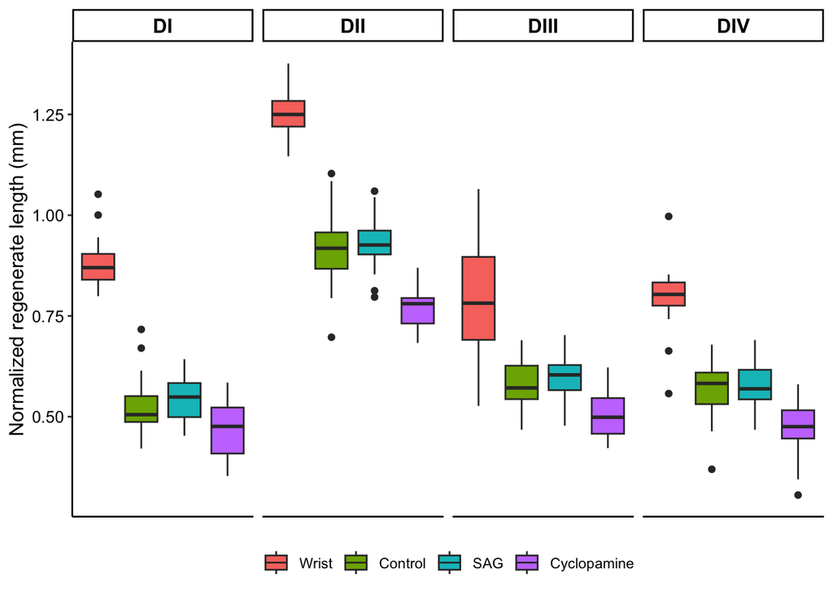

```r
ggplot(merged %>% drop_na(),
       aes(x = factor(Condition,
                      levels = c("Wrist", "Control", "SAG", "Cyclopamine")),
           y = Length,
           fill = factor(Condition,
                         levels = c("Wrist",  "Control", "SAG", "Cyclopamine")))) +
  geom_boxplot() +
  facet_grid(cols = vars(Digit)) +
  xlab(NULL) + ylab("Normalized regenerate length (mm)") +
  theme_classic() +
  theme(legend.title = element_blank(),
        legend.position = "bottom",
        strip.text.x = element_text(color = "black", family = "Arial",
                                    size = 12, face = "bold"),
        axis.text.y = element_text(color = "black", size = 10, family = "Arial"),
        axis.title.y = element_text(family = "Arial", color = "black", size = 12),
        axis.text.x = element_blank(),
        axis.ticks.x = element_blank())
```

#### Statistics

We first perform a Kruskal-Wallis test for each digit to determine if there exists any difference between wrist controls and digit amputations.

```r
digits <- c("DI", "DII", "DIII", "DIV")
conditions <- c("Wrist", "Control", "SAG", "Cyclopamine")

for(digit in digits){
  kw.data <- merged %>% drop_na() %>% filter(Digit == digit)
  print(paste0("Kruskal-Wallis for ", digit))
  res <- kruskal.test(Length ~ Condition, kw.data)
  print(res["p.value"])
}
```

```
## [1] "Kruskal-Wallis for DI"
## $p.value
## [1] 2.962337e-10
##
## [1] "Kruskal-Wallis for DII"
## $p.value
## [1] 6.760125e-13
##
## [1] "Kruskal-Wallis for DIII"
## $p.value
## [1] 2.159442e-09
##
## [1] "Kruskal-Wallis for DIV"
## $p.value
## [1] 8.343479e-11
```

```r
wt.results <- data.frame()
for(digit in digits){
  kw.data <- merged %>% drop_na() %>% filter(Digit == digit)
  for(condition1 in conditions){
    for(condition2 in conditions){
      if(!condition1 == condition2){
      res <- wilcox.test(Length ~ Condition, kw.data,
                     subset = Condition %in% c(condition1, condition2))
      add <- c(Digit = digit, Condition1 = condition1,
               Condition2 = condition2, p.val = res["p.value"])
      wt.results <- rbind(wt.results, add)
      }
    }
  }
}
```

|  | Digit | Condition1 | Condition2 | p.val.p.value |
| --- | --- | --- | --- | --- |
| 1 | DI | Wrist | Control | 5.658467e-11 |
| 2 | DI | Wrist | SAG | 5.658467e-11 |
| 3 | DI | Wrist | Cyclopamine | 5.658467e-11 |
| 4 | DI | Control | Wrist | 5.658467e-11 |
| 5 | DI | Control | SAG | 3.107190e-01 |
| 6 | DI | Control | Cyclopamine | 3.713018e-02 |

### Joint vs. no joint

#### Data cleaning

Performing a similar process as with overall digit length, beginning with student 1.

```r
digits.1 <- read.xlsx("../knitData/Hedgehog_skeletal_measurements_1.xlsx",
                      sheetIndex = 1)[1:20,]
digits.1[11,1] <- "11"
digits.1[11,2] <- "Control"
digits.1[20,13] <- 20
digits.1[20,14] <- "SAG"
digits.1[20,25] <- 20
digits.1[20,26] <- "cyclopamine"
```

|  | Animal | Condition | DI_meta | DI_tip | DII_meta | DII_tip | DIII_meta | DIII_Ph2 | DIII_tip | DIV_meta | DIV_tip | norm | Animal.1 | Condition.1 | DI_meta.1 | DI_tip.1 | DII_meta.1 | DII_tip.1 | DIII_meta.1 | DIII_Ph2.1 | DIII_tip.1 | DIV_meta.1 | DIV_tip.1 | norm.1 | Animal.2 | Condition.2 | DI_meta.2 | DI_tip.2 | DII_meta.2 | … |
| --- | --- | --- | --- | --- | --- | --- | --- | --- | --- | --- | --- | --- | --- | --- | --- | --- | --- | --- | --- | --- | --- | --- | --- | --- | --- | --- | --- | --- | --- | --- |
| 1 | 1 | Control | 0.962 | 0.494 | 1.743 | 0.901 | 2.150 | 1.144 | NA | 1.096 | NA | 1.868 | 1 | SAG | 0.936 | NA | 1.560 | NA | 1.828 | 1.000 | NA | 1.093 | NA | 1.912 | 1 | cyclopamine | 1.053 | NA | 1.307 | … |
| 2 | 2 | Control | 1.152 | 0.692 | 1.758 | 0.852 | 2.193 | 1.148 | NA | 1.164 | NA | 1.896 | 2 | SAG | 1.185 | NA | 2.010 | 1.086 | 2.241 | 1.201 | NA | 1.253 | NA | 2.130 | 2 | cyclopamine | 0.956 | NA | 1.513 | … |
| 3 | 3 | Control | 1.111 | NA | 1.967 | 1.131 | 2.325 | 1.172 | NA | 1.242 | NA | 2.137 | 3 | SAG | 0.876 | NA | 1.658 | NA | 2.160 | 1.116 | NA | 1.044 | NA | 1.953 | 3 | cyclopamine | 0.817 | NA | 1.584 | … |
| 4 | 4 | Control | 1.370 | 0.911 | 1.963 | 1.163 | 2.494 | 1.310 | NA | 1.285 | NA | 2.090 | 4 | SAG | 1.152 | NA | 1.812 | 1.009 | 2.338 | 1.298 | NA | 1.408 | NA | 2.096 | 4 | cyclopamine | 1.072 | NA | 1.372 | … |
| 5 | 5 | Control | 1.085 | 0.582 | 1.897 | 0.998 | 2.202 | 1.094 | NA | 1.056 | NA | 2.110 | 5 | SAG | 1.074 | NA | 1.892 | 0.982 | 2.201 | 1.246 | NA | 1.124 | NA | 2.031 | 5 | cyclopamine | 0.922 | NA | 1.643 | … |
| 6 | 6 | Control | 1.000 | NA | 1.575 | 0.858 | 2.100 | 1.113 | NA | 1.091 | NA | 1.970 | 6 | SAG | 1.086 | 0.675 | 1.616 | 0.877 | 2.072 | 1.210 | NA | 1.078 | NA | 1.800 | 6 | cyclopamine | 0.950 | NA | 1.588 | … |

```r
digits.1.control <- digits.1[-11,] %>%
  select(1:6, 8:12) %>%
  mutate(DI_tip = case_when(is.na(DI_tip) ~ "NO", TRUE ~ "YES"),
         DII_tip = case_when(is.na(DII_tip) ~ "NO", TRUE ~ "YES"),
         DIII_tip = case_when(is.na(DIII_tip) ~ "NO", TRUE ~ "YES"),
         DIV_tip = case_when(is.na(DIV_tip) ~ "NO", TRUE ~ "YES"))

digits.1.control.I <- digits.1.control %>%
  select(1:4, 11) %>%
  mutate(Digit = "DI") %>%
  `colnames<-`(c("Animal", "Condition", "Length", "Has_joint", "Norm", "Digit"))
digits.1.control.II <- digits.1.control %>%
  select(1,2,5,6,11) %>%
  mutate(Digit = "DII") %>%
  `colnames<-`(c("Animal", "Condition", "Length", "Has_joint", "Norm", "Digit"))
digits.1.control.III <- digits.1.control %>%
  select(1,2,7,8,11) %>%
  mutate(Digit = "DIII") %>%
  `colnames<-`(c("Animal", "Condition", "Length", "Has_joint", "Norm", "Digit"))
digits.1.control.IV <- digits.1.control %>%
  select(1,2,9,10,11) %>%
  mutate(Digit = "DIV") %>%
  `colnames<-`(c("Animal", "Condition", "Length", "Has_joint", "Norm", "Digit"))
digits.1.control.all <- rbind(digits.1.control.I, digits.1.control.II,
                          digits.1.control.III, digits.1.control.IV)
```

|  | Animal | Condition | DI_meta | DI_tip | DII_meta | DII_tip | DIII_Ph2 | DIII_tip | DIV_meta | DIV_tip | norm |
| --- | --- | --- | --- | --- | --- | --- | --- | --- | --- | --- | --- |
| 1 | 1 | Control | 0.962 | YES | 1.743 | YES | 1.144 | NO | 1.096 | NO | 1.868 |
| 2 | 2 | Control | 1.152 | YES | 1.758 | YES | 1.148 | NO | 1.164 | NO | 1.896 |
| 3 | 3 | Control | 1.111 | NO | 1.967 | YES | 1.172 | NO | 1.242 | NO | 2.137 |
| 4 | 4 | Control | 1.370 | YES | 1.963 | YES | 1.310 | NO | 1.285 | NO | 2.090 |
| 5 | 5 | Control | 1.085 | YES | 1.897 | YES | 1.094 | NO | 1.056 | NO | 2.110 |
| 6 | 6 | Control | 1.000 | NO | 1.575 | YES | 1.113 | NO | 1.091 | NO | 1.970 |

We repeat the same processing as above for the other conditions and bind all conditions for the final data.

```r
digits.1.SAG <- digits.1[-20,] %>%
  select(13:18, 20:24) %>%
  `colnames<-`(colnames(digits.1.control)) %>%
  mutate(DI_tip = case_when(is.na(DI_tip) ~ "NO", TRUE ~ "YES"),
         DII_tip = case_when(is.na(DII_tip) ~ "NO", TRUE ~ "YES"),
         DIII_tip = case_when(is.na(DIII_tip) ~ "NO", TRUE ~ "YES"),
         DIV_tip = case_when(is.na(DIV_tip) ~ "NO", TRUE ~ "YES"))

digits.1.SAG.I <- digits.1.SAG %>%
  select(1,2,3,4,11) %>%
  mutate(Digit = "DI") %>%
  `colnames<-`(c("Animal", "Condition", "Length", "Has_joint", "Norm", "Digit"))
digits.1.SAG.II <- digits.1.SAG %>%
  select(1,2,5,6,11) %>%
  mutate(Digit = "DII") %>%
  `colnames<-`(c("Animal", "Condition", "Length", "Has_joint", "Norm", "Digit"))
digits.1.SAG.III <- digits.1.SAG %>%
  select(1,2,7,8,11) %>%
  mutate(Digit = "DIII") %>%
  `colnames<-`(c("Animal", "Condition", "Length", "Has_joint", "Norm", "Digit"))
digits.1.SAG.IV <- digits.1.SAG %>%
  select(1,2,9,10,11) %>%
  mutate(Digit = "DIV") %>%
  `colnames<-`(c("Animal", "Condition", "Length", "Has_joint", "Norm", "Digit"))
digits.1.SAG.all <- rbind(digits.1.SAG.I, digits.1.SAG.II,
                      digits.1.SAG.III, digits.1.SAG.IV)
```

```r
digits.1.cyclo <- digits.1[-20,] %>%
  select(25:30,32:36) %>%
  `colnames<-`(colnames(digits.1.control)) %>%
  mutate(DI_tip = case_when(is.na(DI_tip) ~ "NO", TRUE ~ "YES"),
         DII_tip = case_when(is.na(DII_tip) ~ "NO", TRUE ~ "YES"),
         DIII_tip = case_when(is.na(DIII_tip) ~ "NO", TRUE ~ "YES"),
         DIV_tip = case_when(is.na(DIV_tip) ~ "NO", TRUE ~ "YES"))

digits.1.cyclo.I <- digits.1.cyclo %>%
  select(1:4, 11) %>%
  mutate(Digit = "DI")%>%
  `colnames<-`(c("Animal", "Condition", "Length", "Has_joint", "Norm", "Digit"))
digits.1.cyclo.II <- digits.1.cyclo %>%
  select(1,2,5,6,11) %>%
  mutate(Digit = "DII") %>%
  `colnames<-`(c("Animal", "Condition", "Length", "Has_joint", "Norm", "Digit"))
digits.1.cyclo.III <- digits.1.cyclo %>%
  select(1,2,7,8,11) %>%
  mutate(Digit = "DIII") %>%
  `colnames<-`(c("Animal", "Condition", "Length", "Has_joint", "Norm", "Digit"))
digits.1.cyclo.IV <- digits.1.cyclo %>%
  select(1,2,9,10,11) %>%
  mutate(Digit = "DIV") %>%
  `colnames<-`(c("Animal", "Condition", "Length", "Has_joint", "Norm", "Digit"))
digits.1.cyclo.all <- rbind(digits.1.cyclo.I, digits.1.cyclo.II,
                        digits.1.cyclo.III, digits.1.cyclo.IV)
```

```r
wrist.1 <- read.xlsx("../knitData/Hedgehog_skeletal_measurements_1.xlsx",
                     sheetIndex = 2)[1:20,1:12]
wrist.1[11,1] <- "11"
wrist.1[11,2] <- "Control"
wrist.1 <- wrist.1[-11,-7] %>%
  `colnames<-`(colnames(digits.1.control)) %>%
  mutate(DI_tip = case_when(is.na(DI_tip) ~ "NO", TRUE ~ "YES"),
         DII_tip = case_when(is.na(DII_tip) ~ "NO", TRUE ~ "YES"),
         DIII_tip = case_when(is.na(DIII_tip) ~ "NO", TRUE ~ "YES"),
         DIV_tip = case_when(is.na(DIV_tip) ~ "NO", TRUE ~ "YES"),
         Condition = "Wrist")

wrist.1.I <- wrist.1 %>%
  select(1:4, 11) %>%
  mutate(Digit = "DI") %>%
  `colnames<-`(c("Animal", "Condition", "Length", "Has_joint", "Norm", "Digit"))
wrist.1.II <- wrist.1 %>%
  select(1,2,5,6,11) %>%
  mutate(Digit = "DII") %>%
  `colnames<-`(c("Animal", "Condition", "Length", "Has_joint", "Norm", "Digit"))
wrist.1.III <- wrist.1 %>%
  select(1,2,7,8,11) %>%
  mutate(Digit = "DIII") %>%
  `colnames<-`(c("Animal", "Condition", "Length", "Has_joint", "Norm", "Digit"))
wrist.1.IV <- wrist.1 %>%
  select(1,2,9,10,11) %>%
  mutate(Digit = "DIV") %>%
  `colnames<-`(c("Animal", "Condition", "Length", "Has_joint", "Norm", "Digit"))
wrist.1.all <- rbind(wrist.1.I, wrist.1.II,
                 wrist.1.III, wrist.1.IV)
```

```r
digits.1 <- rbind(digits.1.control.all, digits.1.cyclo.all) %>%
  rbind(., digits.1.SAG.all) %>%
  rbind(., wrist.1.all) %>%
  mutate(Has_joint = case_when(Animal == 13 & Condition == "Wrist" ~ "YES",
                               TRUE ~ Has_joint))
```

|  | Animal | Condition | Length | Has_joint | Norm | Digit |
| --- | --- | --- | --- | --- | --- | --- |
| 1 | 1 | Control | 0.962 | YES | 1.868 | DI |
| 2 | 2 | Control | 1.152 | YES | 1.896 | DI |
| 3 | 3 | Control | 1.111 | NO | 2.137 | DI |
| 4 | 4 | Control | 1.370 | YES | 2.090 | DI |
| 5 | 5 | Control | 1.085 | YES | 2.110 | DI |
| 6 | 6 | Control | 1.000 | NO | 1.970 | DI |

We repeat the same processing for the next student’s measurements

```r
digits.2 <- read.xlsx("../knitData/Hedgehog_skeletal_measurements_2.xlsx",
                      sheetIndex = 1)[1:20,]
digits.2[11,1] <- "11"
digits.2[11,2] <- "Control"
digits.2[20,13] <- 20
digits.2[20,14] <- "SAG"
digits.2[20,25] <- 20
digits.2[20,26] <- "cyclopamine"
```

|  | Animal | Condition | DI_meta | DI_tip | DII_meta | DII_tip | DIII_meta | DIII_P2 | DIII_tip | DIV_meta | DIV_tip | norm | Animal.1 | Condition.1 | DI_meta.1 | DI_tip.1 | DII_meta.1 | DII_tip.1 | DIII_meta.1 | DIII_P2.1 | DIII_tip.1 | DIV_meta.1 | DIV_tip.1 | norm.1 | Animal.2 | Condition.2 | DI_meta.2 | DI_tip.2 | DII_meta.2 | … |
| --- | --- | --- | --- | --- | --- | --- | --- | --- | --- | --- | --- | --- | --- | --- | --- | --- | --- | --- | --- | --- | --- | --- | --- | --- | --- | --- | --- | --- | --- | --- |
| 1 | 1 | Control | 0.874 | 0.436 | 1.713 | 0.829 | 2.149 | 1.183 | NA | 1.046 | NA | 1.809 | 1 | SAG | 0.863 | NA | 1.574 | NA | 1.804 | 1.009 | NA | 1.100 | NA | 1.945 | 1 | cyclopamine | 1.147 | NA | 1.785 | … |
| 2 | 2 | Control | 1.118 | 0.634 | 1.743 | 0.910 | 2.178 | 1.194 | NA | 1.091 | NA | 1.854 | 2 | SAG | 1.224 | NA | 1.998 | 1.049 | 2.213 | 1.157 | NA | 1.178 | NA | 2.070 | 2 | cyclopamine | 1.097 | NA | 1.493 | … |
| 3 | 3 | Control | 1.058 | NA | 1.911 | 1.135 | 2.309 | 1.102 | NA | 1.195 | NA | 2.158 | 3 | SAG | 0.899 | NA | 1.687 | NA | 2.113 | 1.178 | NA | 1.013 | NA | 1.968 | 3 | cyclopamine | 0.779 | NA | 1.577 | … |
| 4 | 4 | Control | 1.401 | 0.885 | 2.030 | 1.150 | 2.482 | 1.232 | NA | 1.215 | NA | 2.045 | 4 | SAG | 1.110 | NA | 1.786 | 0.950 | 2.264 | 1.266 | NA | 1.329 | NA | 2.026 | 4 | cyclopamine | 0.999 | NA | 1.331 | … |
| 5 | 5 | Control | 1.018 | 0.582 | 1.855 | 0.899 | 2.172 | 1.058 | NA | 0.980 | NA | 2.097 | 5 | SAG | 1.079 | NA | 1.907 | 0.956 | 2.141 | 1.262 | NA | 1.066 | NA | 1.977 | 5 | cyclopamine | 0.966 | NA | 1.612 | … |
| 6 | 6 | Control | 0.984 | NA | 1.554 | 0.851 | 2.069 | 1.031 | NA | 1.020 | NA | 1.970 | 6 | SAG | 1.075 | 0.675 | 1.714 | 0.850 | 2.129 | 1.240 | NA | 1.117 | NA | 1.844 | 6 | cyclopamine | 0.930 | NA | 1.616 | … |

```r
digits.2.control <- digits.2[-11,] %>%
  select(1:6, 8:12) %>%
  mutate(DI_tip = case_when(is.na(DI_tip) ~ "NO", TRUE ~ "YES"),
         DII_tip = case_when(is.na(DII_tip) ~ "NO", TRUE ~ "YES"),
         DIII_tip = case_when(is.na(DIII_tip) ~ "NO", TRUE ~ "YES"),
         DIV_tip = case_when(is.na(DIV_tip) ~ "NO", TRUE ~ "YES"))

digits.2.control.I <- digits.2.control %>%
  select(1:4, 11) %>%
  mutate(Digit = "DI") %>%
  `colnames<-`(c("Animal", "Condition", "Length", "Has_joint", "Norm", "Digit"))
digits.2.control.II <- digits.2.control %>%
  select(1,2,5,6,11) %>%
  mutate(Digit = "DII") %>%
  `colnames<-`(c("Animal", "Condition", "Length", "Has_joint", "Norm", "Digit"))
digits.2.control.III <- digits.2.control %>%
  select(1,2,7,8,11) %>%
  mutate(Digit = "DIII") %>%
  `colnames<-`(c("Animal", "Condition", "Length", "Has_joint", "Norm", "Digit"))
digits.2.control.IV <- digits.2.control %>%
  select(1,2,9,10,11) %>%
  mutate(Digit = "DIV") %>%
  `colnames<-`(c("Animal", "Condition", "Length", "Has_joint", "Norm", "Digit"))
digits.2.control.all <- rbind(digits.2.control.I, digits.2.control.II,
                          digits.2.control.III, digits.2.control.IV)
```

```r
digits.2.SAG <- digits.2[-20,] %>%
  select(13:18,20:24) %>%
  `colnames<-` (colnames(digits.2.control)) %>%
  mutate(DI_tip = case_when(is.na(DI_tip) ~ "NO", TRUE ~ "YES"),
         DII_tip = case_when(is.na(DII_tip) ~ "NO", TRUE ~ "YES"),
         DIII_tip = case_when(is.na(DIII_tip) ~ "NO", TRUE ~ "YES"),
         DIV_tip = case_when(is.na(DIV_tip) ~ "NO", TRUE ~ "YES"))

digits.2.SAG.I <- digits.2.SAG %>%
  select(1:4, 11) %>%
  mutate(Digit = "DI") %>%
  `colnames<-`(c("Animal", "Condition", "Length", "Has_joint", "Norm", "Digit"))
digits.2.SAG.II <- digits.2.SAG %>%
  select(1,2,5,6,11) %>%
  mutate(Digit = "DII") %>%
  `colnames<-`(c("Animal", "Condition", "Length", "Has_joint", "Norm", "Digit"))
digits.2.SAG.III <- digits.2.SAG %>%
  select(1,2,7,8,11) %>%
  mutate(Digit = "DIII") %>%
  `colnames<-`(c("Animal", "Condition", "Length", "Has_joint", "Norm", "Digit"))
digits.2.SAG.IV <- digits.2.SAG %>%
  select(1,2,9,10,11) %>%
  mutate(Digit = "DIV") %>%
  `colnames<-`(c("Animal", "Condition", "Length", "Has_joint", "Norm", "Digit"))
digits.2.SAG.all <- rbind(digits.2.SAG.I, digits.2.SAG.II,
                      digits.2.SAG.III, digits.2.SAG.IV)
```

```r
digits.2.cyclo <- digits.2[-20,] %>%
  select(25:30,32:36) %>%
  `colnames<-` (colnames(digits.2.control)) %>%
  mutate(DI_tip = case_when(is.na(DI_tip) ~ "NO", TRUE ~ "YES"),
         DII_tip = case_when(is.na(DII_tip) ~ "NO", TRUE ~ "YES"),
         DIII_tip = case_when(is.na(DIII_tip) ~ "NO", TRUE ~ "YES"),
         DIV_tip = case_when(is.na(DIV_tip) ~ "NO", TRUE ~ "YES"))
digits.2.cyclo[7,9] <- NA

digits.2.cyclo.I <- digits.2.cyclo %>%
  select(1:4, 11) %>%
  mutate(Digit = "DI") %>%
  `colnames<-`(c("Animal", "Condition", "Length", "Has_joint", "Norm", "Digit"))
digits.2.cyclo.II <- digits.2.cyclo %>%
  select(1,2,5,6,11) %>%
  mutate(Digit = "DII") %>%
  `colnames<-`(c("Animal", "Condition", "Length", "Has_joint", "Norm", "Digit"))
digits.2.cyclo.III <- digits.2.cyclo %>%
  select(1,2,7,8,11) %>%
  mutate(Digit = "DIII") %>%
  `colnames<-`(c("Animal", "Condition", "Length", "Has_joint", "Norm", "Digit"))
digits.2.cyclo.IV <- digits.2.cyclo %>%
  select(1,2,9,10,11) %>%
  mutate(Digit = "DIV") %>%
  `colnames<-`(c("Animal", "Condition", "Length", "Has_joint", "Norm", "Digit"))
digits.2.cyclo.all <- rbind(digits.2.cyclo.I, digits.2.cyclo.II,
                        digits.2.cyclo.III, digits.2.cyclo.IV)
```

```r
wrist.2 <- read.xlsx("../knitData/Hedgehog_skeletal_measurements_2.xlsx",
                     sheetIndex = 2)
wrist.2[11,1] <- "11"
wrist.2[11,2] <- "Control"
wrist.2 <- wrist.2[-11,-7]
wrist.2 <- wrist.2[,1:11]

wrist.2 <- wrist.2 %>%
  mutate(DI_tip = case_when(is.na(DI_tip) | DI_tip == "?" ~ "NO", TRUE ~ "YES"),
         DII_tip = case_when(is.na(DII_tip) | DII_tip == "?" ~ "NO", TRUE ~ "YES"),
         DIII_tip = case_when(is.na(DIII_tip) | DIII_tip == "?" ~ "NO", TRUE ~ "YES"),
         DIV_tip = case_when(is.na(DIV_tip) | DIV_tip == "?" ~ "NO", TRUE ~ "YES")) %>%
  mutate(Condition = "Wrist") %>%
  `colnames<-`(colnames(digits.2.control))

wrist.2.I <- wrist.2 %>%
  select(1:4, 11) %>%
  mutate(Digit = "DI") %>%
  `colnames<-`(c("Animal", "Condition", "Length", "Has_joint", "Norm", "Digit"))
wrist.2.II <- wrist.2 %>%
  select(1,2,5,6,11) %>%
  mutate(Digit = "DII") %>%
  `colnames<-`(c("Animal", "Condition", "Length", "Has_joint", "Norm", "Digit"))
wrist.2.III <- wrist.2 %>%
  select(1,2,7,8,11) %>%
  mutate(Digit = "DIII") %>%
  `colnames<-`(c("Animal", "Condition", "Length", "Has_joint", "Norm", "Digit"))
wrist.2.IV <- wrist.2 %>%
  select(1,2,9,10,11) %>%
  mutate(Digit = "DIV") %>%
  `colnames<-`(c("Animal", "Condition", "Length", "Has_joint", "Norm", "Digit"))
wrist.2.all <- rbind(wrist.2.I, wrist.2.II,
                 wrist.2.III, wrist.2.IV)
```

```r
digits.2 <- rbind(digits.2.control.all, digits.2.cyclo.all) %>%
  rbind(., digits.2.SAG.all) %>%
  rbind(., wrist.2.all) %>%
  mutate(Has_joint = case_when(Animal == 13 & Condition == "Wrist" ~ "YES",
                               TRUE ~ Has_joint))
```

|  | Animal | Condition | Length | Has_joint | Norm | Digit |
| --- | --- | --- | --- | --- | --- | --- |
| 1 | 1 | Control | 0.874 | YES | 1.809 | DI |
| 2 | 2 | Control | 1.118 | YES | 1.854 | DI |
| 3 | 3 | Control | 1.058 | NO | 2.158 | DI |
| 4 | 4 | Control | 1.401 | YES | 2.045 | DI |
| 5 | 5 | Control | 1.018 | YES | 2.097 | DI |
| 6 | 6 | Control | 0.984 | NO | 1.970 | DI |

Now we join the two students’ cleaned data.

```r
merged <- full_join(digits.1, digits.2, by = c("Animal", "Condition", "Digit"))
merged[267,8] <- "YES" # Adjusted using ground truth from digit fidelity stats
merged <- merged[-140,] # Neither have measurements for 7 cyclo
merged[239,7] <- merged[239,3] # Adjusting using student 2's measurement

merged <- merged %>%
  mutate(Length.x = as.numeric(Length.x),
  Length.y = as.numeric(Length.y)) %>%
  mutate(Norm.x = as.numeric(Norm.x),
         Norm.y = as.numeric(Norm.y))

merged <- merged %>%
  mutate(length = (Length.x + Length.y)/2,
         norm = (Norm.x + Norm.y)/2)
merged <- merged %>%
  select(1,2,6,4,10,11) %>%
  mutate(length = length/norm) %>%
  `colnames<-`(c("Animal", "Condition", "Digit", "Has_joint", "Length", "Norm")) %>%
  mutate(Has_joint = case_when(Has_joint == "YES" ~ "Joint",
                               TRUE ~ "No joint"))
merged <- merged[,1:5]
```

|  | Animal | Condition | Digit | Has_joint | Length |
| --- | --- | --- | --- | --- | --- |
| 1 | 1 | Control | DI | Joint | 0.4993201 |
| 2 | 2 | Control | DI | Joint | 0.6053333 |
| 3 | 3 | Control | DI | No joint | 0.5050058 |
| 4 | 4 | Control | DI | Joint | 0.6701330 |
| 5 | 5 | Control | DI | Joint | 0.4998812 |
| 6 | 6 | Control | DI | No joint | 0.5035533 |

#### Plotting

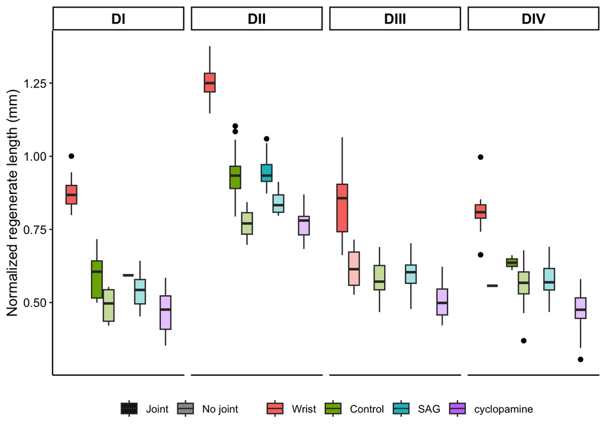

```r
ggplot(merged,
       aes(x = factor(Condition,
                      levels = c("Wrist", "Control", "SAG", "cyclopamine")),
           y = Length,
           group = interaction(Condition, factor(Has_joint,
                                                 levels = c("Joint", "No joint"))),
           alpha = factor(Has_joint, levels = c("Joint", "No joint")),
           fill = factor(Condition,
                         levels = c("Wrist", "Control", "SAG", "cyclopamine")))) +
  geom_boxplot(outlier.color = "black",
               outlier.alpha = 1,
               position = position_dodge2(preserve = "single")) +
  facet_grid(cols = vars(Digit)) +
  xlab(NULL) +
  ylab("Normalized regenerate length (mm)") +
  scale_alpha_manual(breaks = c("Joint", "No joint"),
                     values = c(1, 0.4)) +
  guides(alpha = guide_legend(override.aes = list(fill = c("Joint" = "gray10",
                                                           "No joint"= "gray60"),
                                                  alpha = c(1,1)))) +
  theme_classic() +
  theme(legend.title = element_blank(),
        legend.position = "bottom",
        strip.text.x = element_text(color = "black", family = "Arial",
                                    size = 12, face = "bold"),
        axis.text = element_text(color = "black", size = 10,
                                 family = "Arial"),
        axis.title.y = element_text(family = "Arial", color = "black", size = 12),
        axis.text.x = element_blank(),
        axis.ticks.x = element_blank())
```

#### Statistics

Statistical testing with this dataset is a challenge, given that in many cases there is no comparison; i.e., all digits regenerated with/out a joint. Testing is done below only for cases where some digits regenerated with and without a joint.

```r
print(paste0("Control digit 1 Yes joint vs. No joint: ",
             wilcox.test(Length ~ Has_joint,
            merged,
            subset = Condition == "Control" & Digit == "DI")["p.value"]))
```

```
## [1] "Control digit 1 Yes joint vs. No joint: 0.0283400809716599"
```

```r
print(paste0("Wilcox for SAG digit 1 Yes joint vs. No joint: ",
            wilcox.test(Length ~ Has_joint,
            merged,
            subset = Condition == "SAG" & Digit == "DI")["p.value"]))
```

```
## [1] "Wilcox for SAG digit 1 Yes joint vs. No joint: 0.421052631578947"
```

```r
print(paste0("Wilcox for Control digit 2 Yes joint vs. No joint: ",
             wilcox.test(Length ~ Has_joint,
            merged,
            subset = Condition == "Control" & Digit == "DII")["p.value"]))
```

```
## [1] "Wilcox for Control digit 2 Yes joint vs. No joint: 0.0467836257309941"
```

```r
print(paste0("Wilcox for SAG digit 2 Yes joint vs. No joint: ",
             wilcox.test(Length ~ Has_joint,
            merged,
            subset = Condition == "SAG" & Digit == "DII")["p.value"]))
```

```
## [1] "Wilcox for SAG digit 2 Yes joint vs. No joint: 0.00361197110423117"
```

```r
print(paste0("Wilcox for Wrist digit 3 Yes joint vs. No joint: ",
             wilcox.test(Length ~ Has_joint,
            merged,
            subset = Condition == "Wrist" & Digit == "DIII")["p.value"]))
```

```
## [1] "Wilcox for Wrist digit 3 Yes joint vs. No joint: 0.00361197110423117"
```

```r
print(paste0("Wilcox for Wrist digit 4 Yes joint vs. No joint: ",
             wilcox.test(Length ~ Has_joint,
            merged,
            subset = Condition == "Wrist" & Digit == "DIV")["p.value"]))
```

```
## [1] "Wilcox for Wrist digit 4 Yes joint vs. No joint: 0.105263157894737"
```

```r
print(paste0("Wilcox for Control digit 4 Yes joint vs. No joint: ",
             wilcox.test(Length ~ Has_joint,
            merged,
            subset = Condition == "Control" & Digit == "DIV")["p.value"]))
```

```
## [1] "Wilcox for Control digit 4 Yes joint vs. No joint: 0.105263157894737"
```

## References

Duerr, Timothy J., Eun Kyung Jeon, Kaylee M. Wells, Antonio Villanueva, Ashley W. Seifert, Catherine D. McCusker, and James R. Monaghan. 2022. “A Constitutively Expressed Fluorescent Ubiquitination-Based Cell-Cycle Indicator (FUCCI) in Axolotls for Studying Tissue Regeneration.” *Development* 149 (6): dev199637. https://doi.org/10.1242/dev.199637.

Godwin, James W., Alexander R. Pinto, and Nadia A. Rosenthal. 2013. “Macrophages Are Required for Adult Salamander Limb Regeneration.” *Proceedings of the National Academy of Sciences* 110 (23): 9415–20. https://doi.org/10.1073/pnas.1300290110.

Griffiths, Jackson R., Melissa Miller, Timothy J. Duerr, Ashlin E. Owen, and James R. Monaghan. 2025. “A Characterization of Axolotl Digit Regeneration: Conserved Mechanisms, Divergent Patterning, and a Critical Role for Hedgehog Signaling.” *bioRxiv*. https://doi.org/10.1101/2025.06.03.657663.

Pachitariu, Marius, and Carsen Stringer. 2022. “Cellpose 2.0: How to Train Your Own Model.” *Nature Methods* 19 (12): 1634–41. https://doi.org/10.1038/s41592-022-01663-4.

Stringer, Carsen, and Marius Pachitariu. 2025. “Cellpose3: One-Click Image Restoration for Improved Cellular Segmentation.” *Nature Methods* 22 (3): 592–99. https://doi.org/10.1038/s41592-025-02595-5.

Stringer, Carsen, Tim Wang, Michalis Michaelos, and Marius Pachitariu. 2021. “Cellpose: A Generalist Algorithm for Cellular Segmentation.” *Nature Methods* 18 (1): 100–106. https://doi.org/10.1038/s41592-020-01018-x.